# Analysis of fMRI Data Set (astsa package)

IU M.S. Data Science, Time Series Final Project

Helen Yezerets

April 24, 2019

### References:

1. Chatterjee, S. (2018). Time Series Analysis Using ARIMA Model In R. Retrieved March 25, 2019, from https://datascienceplus.com/time-series-analysis-using-arima-model-in-r/.
2. Coghlan, A. (2010). Using R for Time Series Analysis. Retrieved April 24, 2019, from https://a-little-book-of-r-for-time-series.readthedocs.io/en/latest/src/timeseries.html#time-series-analysis
3. Correlation matrix : A quick start guide to analyze, format and visualize a correlation matrix using R software. (n.d.). Retrieved April 25, 2019, from http://www.sthda.com/english/wiki/correlation-matrix-a-quick-start-guide-to-analyze-format-and-visualize-a-correlation-matrix-using-r-software#compute-correlation-matrix-in-r
4. Cowpertwait, P. S. P., & Metcalfe, A. V. (2009). Introductory Time Series with R.(Ch.6.6 ARMA/ARIMA Models) New York: Springer. https://doi.org/10.1007/978-0-387-88698-5.
5. Shumway, R., & Stooffer, D. S. (2016). Time Series Analysis and Its Applications With R Examples (Fourth Edition).Ch.3. Springer.from http://www.stat.pitt.edu/stoffer/tsa4/

# Data Description

## Description

fMRI data consists of location and stimulus timing related to percieved pain. Stimulus was applied for 32 seconds with 32 seconds waiting period. The sampling rate was one measurement of BOLD (blood oxigenation-level dependent) intensity every 2 seconds for 256 seconds (n = 128). The number of subjects under each condition varies.

## Details

The signal was measured in 9 brain Locations (L): *[1] Cortex 1: Primary Somatosensory, Contralateral (pSS(C)),* [2] Cortex 2: Primary Somatosensory, Ipsilateral (pSS(I)), *[3] Cortex 3: Secondary Somatosensory, Contralateral (sSS(C)),* [4] Cortex 4: Secondary Somatosensory, Ipsilateral (sSS(I)), *[5] Caudate (Cau),* [6] Thalamus 1: Contralateral (Tha(C)), *[7] Thalamus 2: Ipsilateral (Tha(I)),* [8] Cerebellum 1: Contralateral(Crb(C))  
*[9] Cerebellum 2: Ipsilateral (Crb(I)).

The stimuli (T) with the number of respective sujects: *[1] Awake-Brush (5 subjects),* [2] Awake-Heat (4 subjects), *[3] Awake-Shock (5 subjects),* [4] Low-Brush (3 subjects), *[5] Low-Heat (5 subjects), and* [6] Low-Shock (4 subjects).

Example: fmri$L1T6 (as well as fmri[[6]]) (Location 1, Treatment 6) will show the data for Cortex 1: Primary Somatosensory, Contralateral location with Low-Shock (4 subjects) treatment

```r
#Need astsa package
#install.packages("astsa")
library(astsa)
```

## variable description and its statistical summary: mean, sd, min, max

```r
#Explore fmri data
str(fmri)
```

```
## List of 54
##  $ L1T1: num [1:128, 1:5] -0.154 0.154 0.269 0.192 0.462 ...
##  $ L1T2: num [1:128, 1:4] -0.0952 -0.2381 0.381 0.5238 0.0952 ...
##  $ L1T3: num [1:128, 1:5] -0.4546 -0.6818 0.1364 0 -0.0455 ...
##  $ L1T4: num [1:128, 1:3] 0 -0.222 0.111 -0.333 0.5 ...
##  $ L1T5: num [1:128, 1:5] -0.3333 0.25 0.75 0.0833 0.4167 ...
##  $ L1T6: num [1:128, 1:4] 0.2 -0.267 -0.2 -0.667 -0.2 ...
##  $ L2T1: num [1:128, 1:5] 0.15 -0.05 -0.25 -0.15 -0.35 0.2 -0.3 -0.4 -0.45 -0.65 ...
##  $ L2T2: num [1:128, 1:4] 0.2083 0.9167 0.4167 0.0417 0 ...
##  $ L2T3: num [1:128, 1:5] 0.6154 1 0.6154 0.2308 -0.0769 ...
##  $ L2T4: num [1:128, 1:3] 0.0952 0 -0.0952 0 -0.3333 ...
##  $ L2T5: num [1:128, 1:5] 0.2143 0.1429 -0.0714 1 0 ...
##  $ L2T6: num [1:128, 1:4] 0.0345 -0.4138 -0.3103 0 -0.1724 ...
##  $ L3T1: num [1:128, 1:5] -0.7059 -0.3529 -0.2941 0.0588 0.1765 ...
##  $ L3T2: num [1:128, 1:4] -0.3529 -0.2353 -0.0588 0.2941 0.2941 ...
```

[output cut: 40 more lines]

### Let’s explore one of the Location-Stimulus pair: L1 (pSSC) for T2 (Awake Heat)

```r
#Check the type of L1T2
class(fmri$L1T2)
```

```
## [1] "matrix"
```

```r
#show first 6 lines
head(fmri$L1T2)
```

```
##           [,1]      [,2]   [,3]  [,4]
## [1,] -0.095238 -0.733333 -0.025  0.50
## [2,] -0.238095 -0.800000  0.050 -0.45
## [3,]  0.380952 -0.133333  0.150 -0.15
## [4,]  0.523810  0.333333  0.375 -0.35
## [5,]  0.095238  0.200000  0.400  0.10
## [6,]  0.190476  0.000000  0.125 -0.10
```

```r
#show last 6 lines
tail(fmri$L1T2)
```

```
##             [,1]      [,2]   [,3]  [,4]
## [123,] -0.619048  0.133333 -0.325  0.00
## [124,] -0.523810 -1.000000  0.250  0.05
## [125,] -0.095238 -0.333333 -0.225 -0.20
## [126,] -0.761905 -0.666667 -0.375 -0.30
## [127,]  0.000000 -0.400000 -0.125  0.20
## [128,] -0.714286 -0.133333 -0.300  0.35
```

```r
#check if the data is time series
is.ts(fmri$L1T2)
```

```
## [1] FALSE
```

```r
#Convert to ts
fmri_AH1.ts<-ts(fmri$L1T2, frequency = 64)
class(fmri_AH1.ts)
```

```
## [1] "mts"    "ts"     "matrix"
```

```r
#view the times
time(fmri_AH1.ts)
```

```
## Time Series:
## Start = c(1, 1)
## End = c(2, 64)
## Frequency = 64
##   [1] 1.000000 1.015625 1.031250 1.046875 1.062500 1.078125 1.093750
##   [8] 1.109375 1.125000 1.140625 1.156250 1.171875 1.187500 1.203125
##  [15] 1.218750 1.234375 1.250000 1.265625 1.281250 1.296875 1.312500
##  [22] 1.328125 1.343750 1.359375 1.375000 1.390625 1.406250 1.421875
##  [29] 1.437500 1.453125 1.468750 1.484375 1.500000 1.515625 1.531250
##  [36] 1.546875 1.562500 1.578125 1.593750 1.609375 1.625000 1.640625
##  [43] 1.656250 1.671875 1.687500 1.703125 1.718750 1.734375 1.750000
##  [50] 1.765625 1.781250 1.796875 1.812500 1.828125 1.843750 1.859375
##  [57] 1.875000 1.890625 1.906250 1.921875 1.937500 1.953125 1.968750
##  [64] 1.984375 2.000000 2.015625 2.031250 2.046875 2.062500 2.078125
##  [71] 2.093750 2.109375 2.125000 2.140625 2.156250 2.171875 2.187500
##  [78] 2.203125 2.218750 2.234375 2.250000 2.265625 2.281250 2.296875
##  [85] 2.312500 2.328125 2.343750 2.359375 2.375000 2.390625 2.406250
##  [92] 2.421875 2.437500 2.453125 2.468750 2.484375 2.500000 2.515625
##  [99] 2.531250 2.546875 2.562500 2.578125 2.593750 2.609375 2.625000
## [106] 2.640625 2.656250 2.671875 2.687500 2.703125 2.718750 2.734375
## [113] 2.750000 2.765625 2.781250 2.796875 2.812500 2.828125 2.843750
## [120] 2.859375 2.875000 2.890625 2.906250 2.921875 2.937500 2.953125
## [127] 2.968750 2.984375
```

```r
#Column summary for individual subjects
summary(fmri_AH1.ts)
```

```
##     Series 1           Series 2            Series 3
##  Min.   :-0.76191   Min.   :-1.000000   Min.   :-1.0000000
##  1st Qu.:-0.19048   1st Qu.:-0.266667   1st Qu.:-0.2250000
##  Median : 0.00000   Median : 0.000000   Median : 0.0000000
##  Mean   :-0.01004   Mean   :-0.004687   Mean   : 0.0005859
##  3rd Qu.: 0.19048   3rd Qu.: 0.266667   3rd Qu.: 0.2250000
##  Max.   : 1.00000   Max.   : 1.000000   Max.   : 0.7500000
##     Series 4
##  Min.   :-1.0000000
##  1st Qu.:-0.2500000
##  Median : 0.0000000
##  Mean   :-0.0003906
##  3rd Qu.: 0.2000000
##  Max.   : 0.8000000
```

## ts description: start, end, frequency

```r
start(fmri_AH1.ts)
```

```
## [1] 1 1
```

```r
end(fmri_AH1.ts)
```

```
## [1]  2 64
```

```r
frequency(fmri_AH1.ts)
```

```
## [1] 64
```

```r
cycle(fmri_AH1.ts)
```

```
## Time Series:
## Start = c(1, 1)
## End = c(2, 64)
## Frequency = 64
##   [1]  1  2  3  4  5  6  7  8  9 10 11 12 13 14 15 16 17 18 19 20 21 22 23
##  [24] 24 25 26 27 28 29 30 31 32 33 34 35 36 37 38 39 40 41 42 43 44 45 46
##  [47] 47 48 49 50 51 52 53 54 55 56 57 58 59 60 61 62 63 64  1  2  3  4  5
##  [70]  6  7  8  9 10 11 12 13 14 15 16 17 18 19 20 21 22 23 24 25 26 27 28
##  [93] 29 30 31 32 33 34 35 36 37 38 39 40 41 42 43 44 45 46 47 48 49 50 51
## [116] 52 53 54 55 56 57 58 59 60 61 62 63 64
```

# Data Exploration

## plotting multiple locations for the same stimulus data

### Awake-Heat

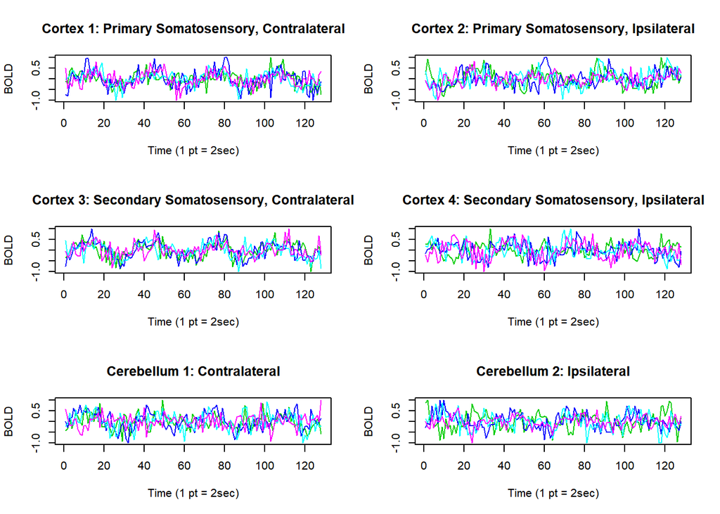

```r
par(mfrow=c(3,2))
#Explore T2 on all of the cortex zones
ts.plot(as.ts(fmri$L1T2), col=3:7, main="Cortex 1: Primary Somatosensory, Contralateral", ylab="BOLD", xlab="Time (1 pt = 2sec)")
ts.plot(as.ts(fmri$L2T2), col=3:7, main="Cortex 2: Primary Somatosensory, Ipsilateral", ylab="BOLD", xlab="Time (1 pt = 2sec)")
ts.plot(as.ts(fmri$L3T2),col=3:7, main="Cortex 3: Secondary Somatosensory, Contralateral", ylab="BOLD", xlab="Time (1 pt = 2sec)")
ts.plot(as.ts(fmri$L4T2),col=3:7, main="Cortex 4: Secondary Somatosensory, Ipsilateral", ylab="BOLD", xlab="Time (1 pt = 2sec)")

ts.plot(as.ts(fmri$L8T2),col=3:7, main="Cerebellum 1: Contralateral", ylab="BOLD", xlab="Time (1 pt = 2sec)")
ts.plot(as.ts(fmri$L9T2),col=3:7, main="Cerebellum 2: Ipsilateral", ylab="BOLD", xlab="Time (1 pt = 2sec)")
```

Observations: In response to Awake-Heat stimulation * Both Contralateral Cortex zone show potential strong correlation and cyclic increase in BOLD response in 16, 45, 77 and 110 sec that resembles a gradual addaptation to the stimulus. * On the other hand, the Primary Ipsilateral zone reacts with a steady increase, with a max at the 32 sec of the stimulus during the first application, however the second stimulus produces two picks: 32 sec and 64. * The secondary Ipsilateral zone follows the Contralateral zone pattern with higher variability of the BOLD response signal * Cerebellum exibits response to the stimulus similar to the Cortex Secondary zone with slightly less pronounced cyclic variations

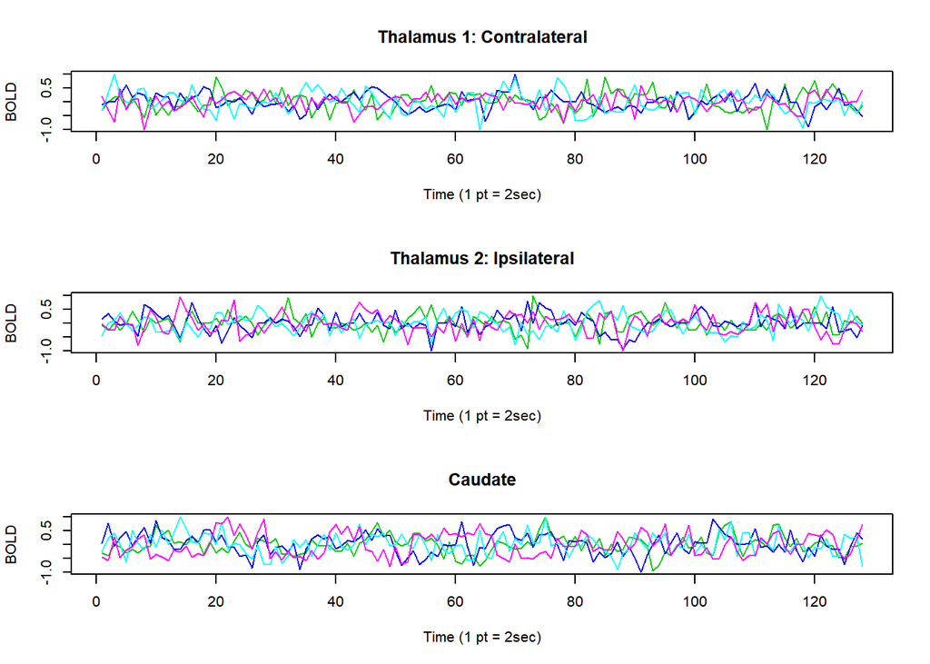

```r
#Explore the basal brain zone
par(mfrow=c(3,1))
ts.plot(as.ts(fmri$L6T2),col=3:7, main="Thalamus 1: Contralateral", ylab="BOLD", xlab="Time (1 pt = 2sec)")
ts.plot(as.ts(fmri$L7T2),col=3:7, main="Thalamus 2: Ipsilateral", ylab="BOLD", xlab="Time (1 pt = 2sec)")
ts.plot(as.ts(fmri$L5T2),col=3:7, main="Caudate", ylab="BOLD", xlab="Time (1 pt = 2sec)")
```

The basal structures appear to respond as a WN. Need further investigation

## Data transformation:

Current data is per test subject that makes it harder for analysis. Aggregation by mean would clarify the trends of the data. Log transformation is not appropriate since the range and variancies of BOLD values are relatively small and do not exhibit rapid growth pattern over time.

```r
#Check row means
rowMeans(fmri_AH1.ts)
```

```
##   [1] -0.08839275 -0.35952375  0.06190475  0.22053575  0.19880950
##   [6]  0.05386900  0.05089275 -0.11250000  0.13898800  0.18214275
##  [11]  0.20386900  0.51160700  0.10208325  0.25267850  0.33363100
##  [16]  0.39494050  0.09107150  0.32678575  0.16666675 -0.16904750
##  [21] -0.11666675 -0.12708325 -0.09077375 -0.36101200 -0.15148800
##  [26] -0.39702375 -0.26398800 -0.09702400 -0.39375000 -0.44375000
##  [31] -0.16369050 -0.19761900 -0.05178575 -0.25029750 -0.07232150
##  [36]  0.11458325  0.27261925  0.03690475  0.03750000  0.08571425
##  [41]  0.45416675  0.04523825  0.31517850  0.31696425  0.34791650
##  [46]  0.22559525  0.23392850  0.31607150  0.20446425  0.17767850
##  [51]  0.00267850 -0.06309525 -0.17053575 -0.04345250  0.09285725
##  [56] -0.36279775 -0.11815475 -0.32202375 -0.12529750 -0.07946425
##  [61] -0.23214275 -0.22738100 -0.13928575 -0.15178575 -0.12113075
##  [66] -0.19017850 -0.19255950  0.01011900  0.03154775  0.10327375
##  [71] -0.02916675  0.24583325  0.31934525  0.19107150  0.35684525
##  [76] -0.00148800  0.26428575  0.26488075  0.48422600  0.42619050
##  [81]  0.49017850  0.21041675 -0.10744050 -0.12440475 -0.07113100
##  [86] -0.22470250 -0.44107125 -0.30446425 -0.31517850 -0.14791675
##  [91]  0.11458325 -0.48303575 -0.27797625 -0.21071425 -0.12053575
##  [96] -0.16994050 -0.07529750 -0.13273800  0.01875000 -0.01339275
## [101]  0.18511900  0.08660700  0.13958325  0.31755950  0.13988100
## [106]  0.34821425  0.42142875  0.21577400  0.38869050  0.01398800
## [111]  0.21220225  0.14226175 -0.04226200  0.03541650 -0.27619050
## [116] -0.28095250 -0.15119050 -0.29613100 -0.21011925 -0.06369050
## [121] -0.40416650 -0.26309525 -0.20267875 -0.30595250 -0.21339275
## [126] -0.52589300 -0.08125000 -0.19940475
```

```r
#combine brain zones per stimulus using row means

#[1] Awake-Brush (5 subjects)
fmri_ABrush<-cbind(rowMeans(fmri$L1T1), rowMeans(fmri$L2T1), rowMeans(fmri$L3T1), rowMeans(fmri$L4T1), rowMeans(fmri$L5T1),  rowMeans(fmri$L6T1), rowMeans(fmri$L7T1), rowMeans(fmri$L8T1), rowMeans(fmri$L9T1))

#[2] Awake-Heat (4 subjects)
fmri_AHeat<-cbind(rowMeans(fmri$L1T2), rowMeans(fmri$L2T2), rowMeans(fmri$L3T2), rowMeans(fmri$L4T2), rowMeans(fmri$L5T2),  rowMeans(fmri$L6T2), rowMeans(fmri$L7T2), rowMeans(fmri$L8T2), rowMeans(fmri$L9T2))
#add column names
colnames(fmri_AHeat) <-c("pSS(C)", "pSS(I)","sSS(C)", "sSS(I)", "Cau", "Tha(C)","Tha(I)", "Crb(C)", "Crb(I)")


#[3] Awake-Shock (5 subjects),
fmri_AShock<-cbind(rowMeans(fmri$L1T3), rowMeans(fmri$L2T3), rowMeans(fmri$L3T3), rowMeans(fmri$L4T3), rowMeans(fmri$L5T3),  rowMeans(fmri$L6T3), rowMeans(fmri$L7T3), rowMeans(fmri$L8T3), rowMeans(fmri$L9T3))
#add column names for Sedated Heat
colnames(fmri_AShock) <-c("pSS(C)", "pSS(I)","sSS(C)", "sSS(I)", "Cau", "Tha(C)","Tha(I)", "Crb(C)", "Crb(I)")

#[4] Low-Brush (3 subjects),
fmri_SBrush<-cbind(rowMeans(fmri$L1T4), rowMeans(fmri$L2T4), rowMeans(fmri$L3T4), rowMeans(fmri$L4T4), rowMeans(fmri$L5T4),  rowMeans(fmri$L6T4), rowMeans(fmri$L7T4), rowMeans(fmri$L8T4), rowMeans(fmri$L9T4))

#[5] Low-Heat (5 subjects),
fmri_SHeat<-cbind(rowMeans(fmri$L1T5), rowMeans(fmri$L2T5), rowMeans(fmri$L3T5), rowMeans(fmri$L4T5), rowMeans(fmri$L5T5),  rowMeans(fmri$L6T5), rowMeans(fmri$L7T5), rowMeans(fmri$L8T5), rowMeans(fmri$L9T5))
#add column names for Sedated Heat
colnames(fmri_SHeat) <-c("pSS(C)", "pSS(I)","sSS(C)", "sSS(I)", "Cau", "Tha(C)","Tha(I)", "Crb(C)", "Crb(I)")


#[6] Low-Shock (4 subjects).
fmri_SShock<-cbind(rowMeans(fmri$L1T6), rowMeans(fmri$L2T6), rowMeans(fmri$L3T6), rowMeans(fmri$L4T6), rowMeans(fmri$L5T6),  rowMeans(fmri$L6T6), rowMeans(fmri$L7T6), rowMeans(fmri$L8T6), rowMeans(fmri$L9T6))
#add column names for Sedated Heat
colnames(fmri_SShock) <-c("pSS(C)", "pSS(I)","sSS(C)", "sSS(I)", "Cau", "Tha(C)","Tha(I)", "Crb(C)", "Crb(I)")
```

## Depict response to Heat by various brain zones

### Awake

```r
summary(fmri_AHeat)
```

```
##      pSS(C)              pSS(I)               sSS(C)
##  Min.   :-0.525893   Min.   :-0.4950162   Min.   :-0.6662837
##  1st Qu.:-0.175446   1st Qu.:-0.1649408   1st Qu.:-0.1822410
##  Median :-0.035714   Median :-0.0097834   Median :-0.0081404
##  Mean   :-0.003634   Mean   : 0.0008904   Mean   :-0.0008448
##  3rd Qu.: 0.193006   3rd Qu.: 0.1621356   3rd Qu.: 0.2027579
##  Max.   : 0.511607   Max.   : 0.5319445   Max.   : 0.6153580
##      sSS(I)               Cau                Tha(C)
##  Min.   :-0.468389   Min.   :-0.444535   Min.   :-0.360009
##  1st Qu.:-0.118192   1st Qu.:-0.095756   1st Qu.:-0.079749
##  Median :-0.013950   Median : 0.005980   Median : 0.005483
##  Mean   :-0.001296   Mean   : 0.004699   Mean   : 0.003157
##  3rd Qu.: 0.141891   3rd Qu.: 0.142871   3rd Qu.: 0.090882
##  Max.   : 0.361817   Max.   : 0.549036   Max.   : 0.516544
##      Tha(I)              Crb(C)              Crb(I)
##  Min.   :-0.407575   Min.   :-0.455586   Min.   :-0.709375
##  1st Qu.:-0.114773   1st Qu.:-0.126374   1st Qu.:-0.096875
##  Median : 0.015602   Median : 0.027015   Median : 0.003795
##  Mean   : 0.000543   Mean   : 0.005298   Mean   : 0.008238
##  3rd Qu.: 0.107588   3rd Qu.: 0.122253   3rd Qu.: 0.132254
##  Max.   : 0.348579   Max.   : 0.463370   Max.   : 0.397321
```

```r
class(fmri_AHeat)
```

```
## [1] "matrix"
```

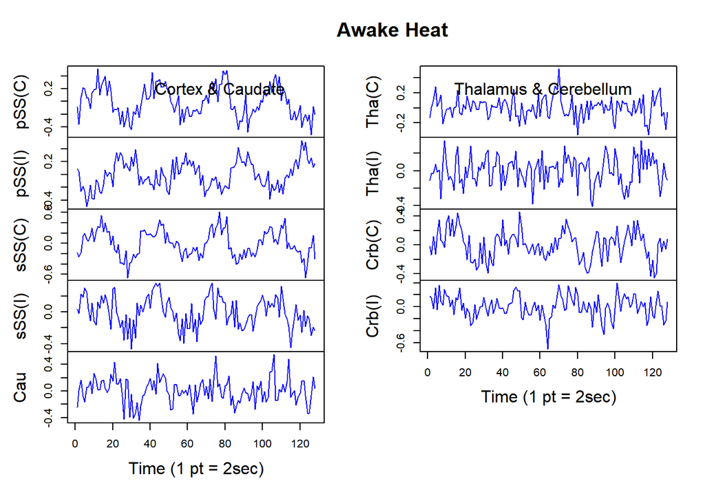

```r
plot.ts(fmri_AHeat,col=4,xlab="Time (1 pt = 2sec)", main="Awake Heat")

#Show subtitle on a side of the plot (1=bottom, 2=left, 3=top, 4=right)
mtext("Cortex & Caudate", side=3, adj=.05, line=-0.8)
mtext("Thalamus & Cerebellum", side=3, adj=.95, line=-0.8)
```

# Regression with summaries

```r
#Fit data
fmri_AHeat.ts<-as.ts(fmri_AHeat, frequency = 64)
```

```r
#Fit the regression model and provide summary

summary(fit3 <- lm(fmri_AHeat.ts~time(fmri_AHeat.ts), na.action=NULL))
```

```
## Response pSS(C) :
##
## Call:
## lm(formula = `pSS(C)` ~ time(fmri_AHeat.ts), na.action = NULL)
##
## Residuals:
##      Min       1Q   Median       3Q      Max
## -0.47837 -0.17222 -0.00849  0.18904  0.51211
##
## Coefficients:
##                       Estimate Std. Error t value Pr(>|t|)
## (Intercept)          0.0678762  0.0424316   1.600   0.1122
## time(fmri_AHeat.ts) -0.0011087  0.0005708  -1.942   0.0543 .
## ---
## Signif. codes:  0 '***' 0.001 '**' 0.01 '*' 0.05 '.' 0.1 ' ' 1
##
## Residual standard error: 0.2386 on 126 degrees of freedom
## Multiple R-squared:  0.02907,    Adjusted R-squared:  0.02136
## F-statistic: 3.772 on 1 and 126 DF,  p-value: 0.05434
##
##
## Response pSS(I) :
##
## Call:
## lm(formula = `pSS(I)` ~ time(fmri_AHeat.ts), na.action = NULL)
##
## Residuals:
##      Min       1Q   Median       3Q      Max
## -0.43370 -0.15921  0.00408  0.15255  0.45653
##
## Coefficients:
##                      Estimate Std. Error t value Pr(>|t|)
## (Intercept)         -0.084185   0.036719  -2.293  0.02352 *
## time(fmri_AHeat.ts)  0.001319   0.000494   2.670  0.00858 **
## ---
## Signif. codes:  0 '***' 0.001 '**' 0.01 '*' 0.05 '.' 0.1 ' ' 1
##
## Residual standard error: 0.2065 on 126 degrees of freedom
## Multiple R-squared:  0.05356,    Adjusted R-squared:  0.04604
## F-statistic:  7.13 on 1 and 126 DF,  p-value: 0.008581
```

[output cut: 120 more lines]

```
## Call:
## lm(formula = `Crb(I)` ~ time(fmri_AHeat.ts), na.action = NULL)
##
## Residuals:
##      Min       1Q   Median       3Q      Max
## -0.71789 -0.09928 -0.00007  0.11768  0.40966
##
## Coefficients:
##                       Estimate Std. Error t value Pr(>|t|)
## (Intercept)          0.0445968  0.0330715   1.348    0.180
## time(fmri_AHeat.ts) -0.0005637  0.0004449  -1.267    0.207
##
## Residual standard error: 0.186 on 126 degrees of freedom
## Multiple R-squared:  0.01258,    Adjusted R-squared:  0.004744
## F-statistic: 1.605 on 1 and 126 DF,  p-value: 0.2075
```

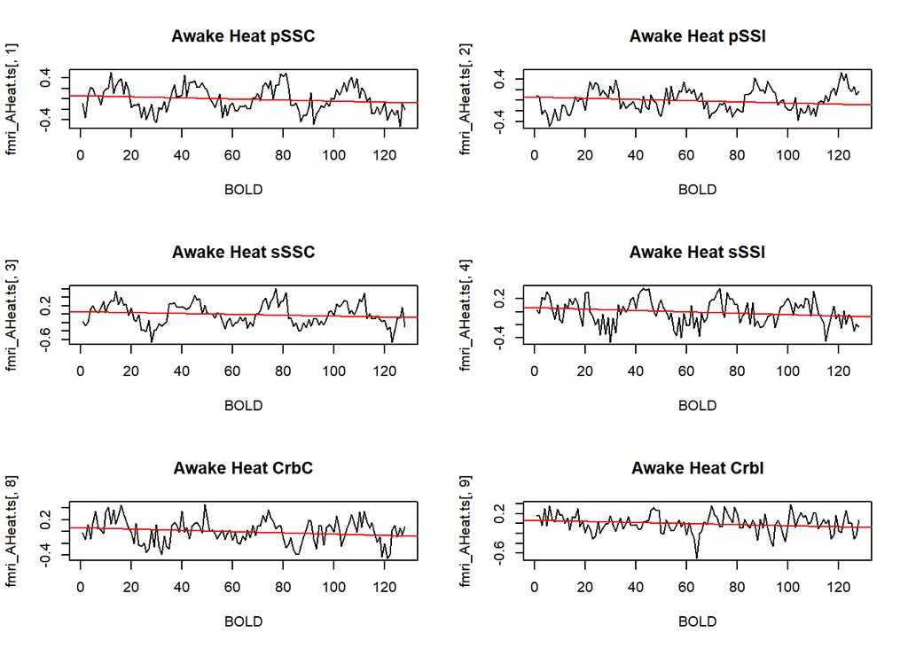

```r
#Plot by location
par(mfrow=c(3,2))
plot(fmri_AHeat.ts[,1], main="Awake Heat pSSC", xlab="BOLD")
abline(fit3, col=2) # add the fitted line
plot(fmri_AHeat.ts[,2], main="Awake Heat pSSI", xlab="BOLD")
abline(fit3, col=2) # add the fitted line
plot(fmri_AHeat.ts[,3], main="Awake Heat sSSC", xlab="BOLD")
abline(fit3, col=2) # add the fitted line
plot(fmri_AHeat.ts[,4], main="Awake Heat sSSI", xlab="BOLD")
abline(fit3, col=2) # add the fitted line
plot(fmri_AHeat.ts[,8], main="Awake Heat CrbC", xlab="BOLD")
abline(fit3, col=2) # add the fitted line
plot(fmri_AHeat.ts[,9], main="Awake Heat CrbI", xlab="BOLD")
abline(fit3, col=2) # add the fitted line
```

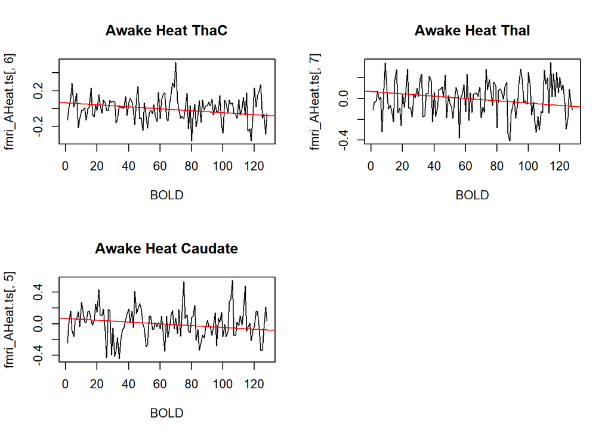

```r
par(mfrow=c(2,2))
plot(fmri_AHeat.ts[,6], main="Awake Heat ThaC", xlab="BOLD")
abline(fit3, col=2) # add the fitted line
plot(fmri_AHeat.ts[,7], main="Awake Heat ThaI", xlab="BOLD")
abline(fit3, col=2) # add the fitted line
plot(fmri_AHeat.ts[,5], main="Awake Heat Caudate", xlab="BOLD")
abline(fit3, col=2) # add the fitted line
```

```r
#Regression with differenced data lag=14

summary(fit.ts<-lm(fmri_AHeat.ts[14:127]~diff(fmri_AHeat.ts, lag=14)))
```

```
##
## Call:
## lm(formula = fmri_AHeat.ts[14:127] ~ diff(fmri_AHeat.ts, lag = 14))
##
## Residuals:
##      Min       1Q   Median       3Q      Max
## -0.58291 -0.11545  0.01058  0.10232  0.44973
##
## Coefficients:
##                                       Estimate Std. Error t value Pr(>|t|)
## (Intercept)                          0.0033899  0.0159128   0.213 0.831723
## diff(fmri_AHeat.ts, lag = 14)pSS(C)  0.1405633  0.0817582   1.719 0.088543
## diff(fmri_AHeat.ts, lag = 14)pSS(I)  0.0825410  0.0840621   0.982 0.328425
## diff(fmri_AHeat.ts, lag = 14)sSS(C)  0.2485713  0.0710886   3.497 0.000694
## diff(fmri_AHeat.ts, lag = 14)sSS(I) -0.0326695  0.0768008  -0.425 0.671439
## diff(fmri_AHeat.ts, lag = 14)Cau    -0.0004584  0.0648754  -0.007 0.994376
## diff(fmri_AHeat.ts, lag = 14)Tha(C) -0.1083498  0.0837607  -1.294 0.198682
## diff(fmri_AHeat.ts, lag = 14)Tha(I) -0.1299848  0.0694061  -1.873 0.063902
## diff(fmri_AHeat.ts, lag = 14)Crb(C)  0.0629706  0.0667138   0.944 0.347413
## diff(fmri_AHeat.ts, lag = 14)Crb(I)  0.1642261  0.0729275   2.252 0.026430
##
## (Intercept)
## diff(fmri_AHeat.ts, lag = 14)pSS(C) .
## diff(fmri_AHeat.ts, lag = 14)pSS(I)
## diff(fmri_AHeat.ts, lag = 14)sSS(C) ***
## diff(fmri_AHeat.ts, lag = 14)sSS(I)
## diff(fmri_AHeat.ts, lag = 14)Cau
## diff(fmri_AHeat.ts, lag = 14)Tha(C)
## diff(fmri_AHeat.ts, lag = 14)Tha(I) .
## diff(fmri_AHeat.ts, lag = 14)Crb(C)
## diff(fmri_AHeat.ts, lag = 14)Crb(I) *
## ---
## Signif. codes:  0 '***' 0.001 '**' 0.01 '*' 0.05 '.' 0.1 ' ' 1
##
## Residual standard error: 0.1673 on 104 degrees of freedom
## Multiple R-squared:  0.567,  Adjusted R-squared:  0.5295
## F-statistic: 15.13 on 9 and 104 DF,  p-value: 1.824e-15
```

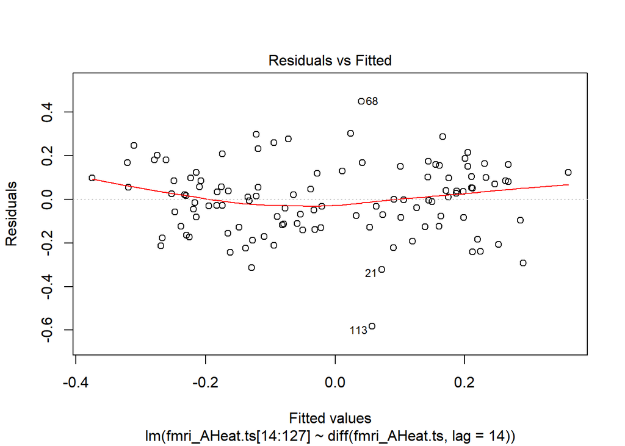

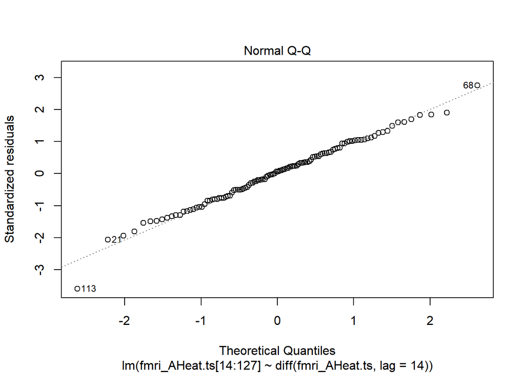

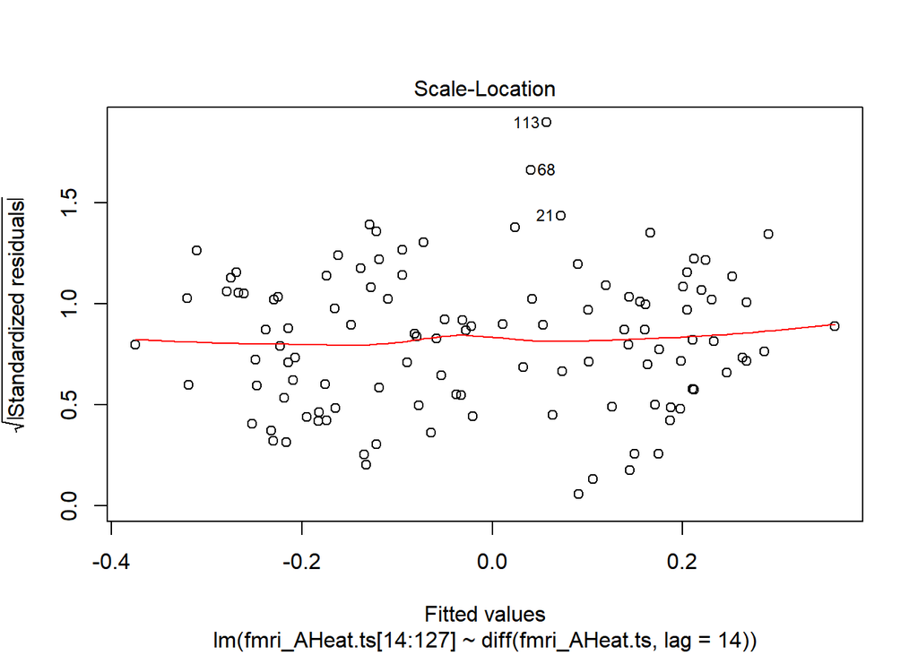

```r
plot(fit.ts)
```

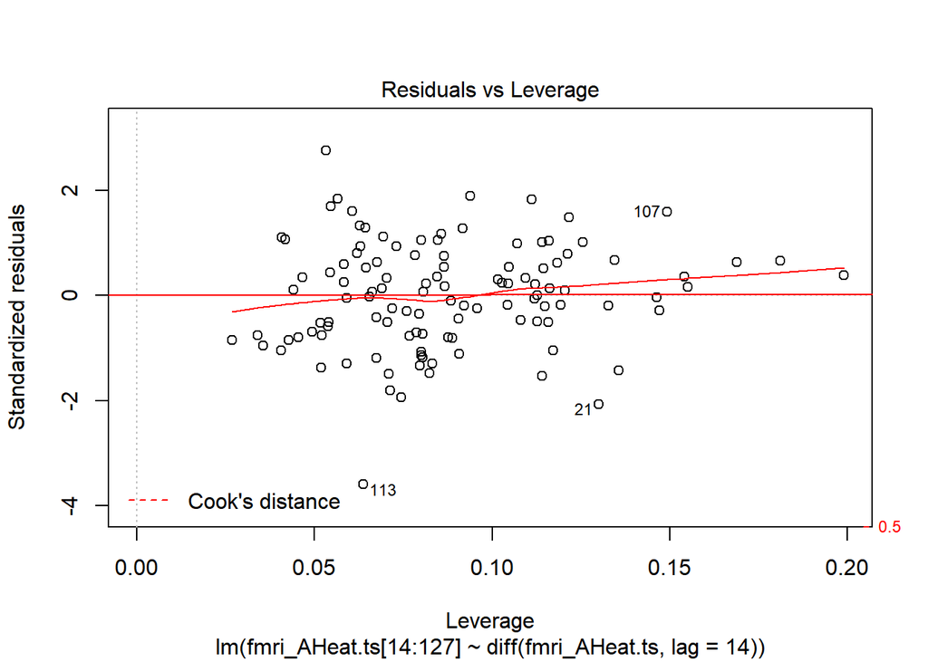

```r
abline(fit.ts, col=2)
```

## Scatter and box plot across cycles with with abline

### Compare primary and secondary SS(C) and SS(I)

```r
#fmri_AHeat[,2]
summary(fit<-lm(fmri_AHeat[10:127,1]~diff(fmri_AHeat[,1], lag=10)))
```

```
##
## Call:
## lm(formula = fmri_AHeat[10:127, 1] ~ diff(fmri_AHeat[, 1], lag = 10))
##
## Residuals:
##      Min       1Q   Median       3Q      Max
## -0.55442 -0.14258 -0.03336  0.16200  0.49779
##
## Coefficients:
##                                 Estimate Std. Error t value Pr(>|t|)
## (Intercept)                      0.00454    0.01930   0.235    0.814
## diff(fmri_AHeat[, 1], lag = 10)  0.34303    0.05072   6.763 5.77e-10 ***
## ---
## Signif. codes:  0 '***' 0.001 '**' 0.01 '*' 0.05 '.' 0.1 ' ' 1
##
## Residual standard error: 0.2093 on 116 degrees of freedom
## Multiple R-squared:  0.2828, Adjusted R-squared:  0.2766
## F-statistic: 45.74 on 1 and 116 DF,  p-value: 5.771e-10
```

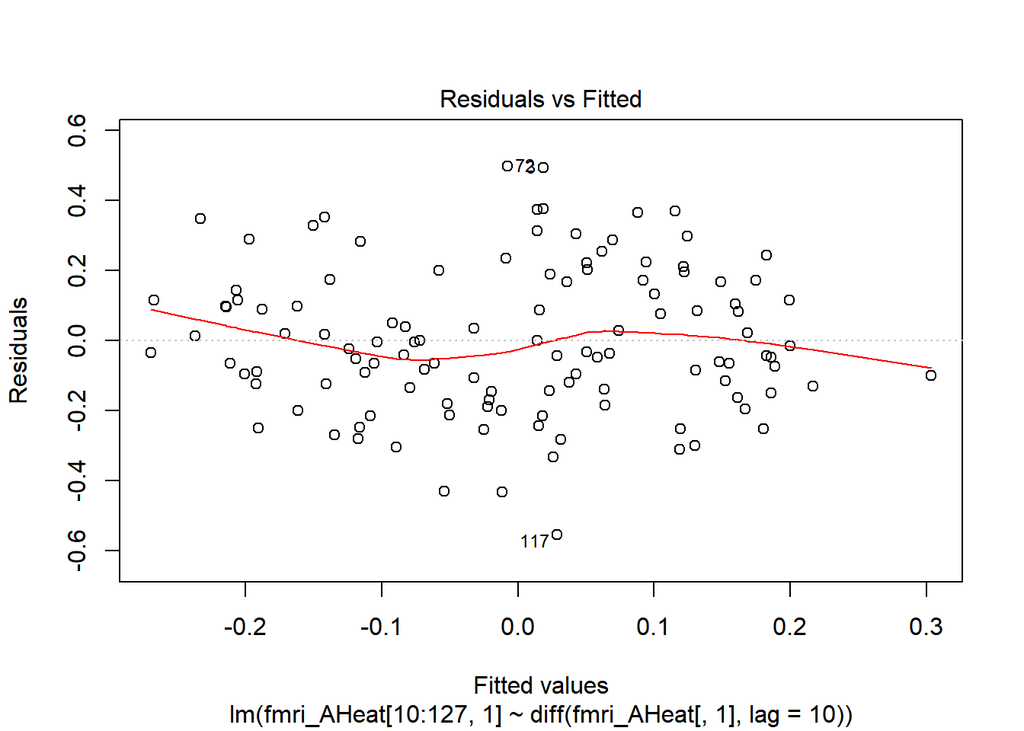

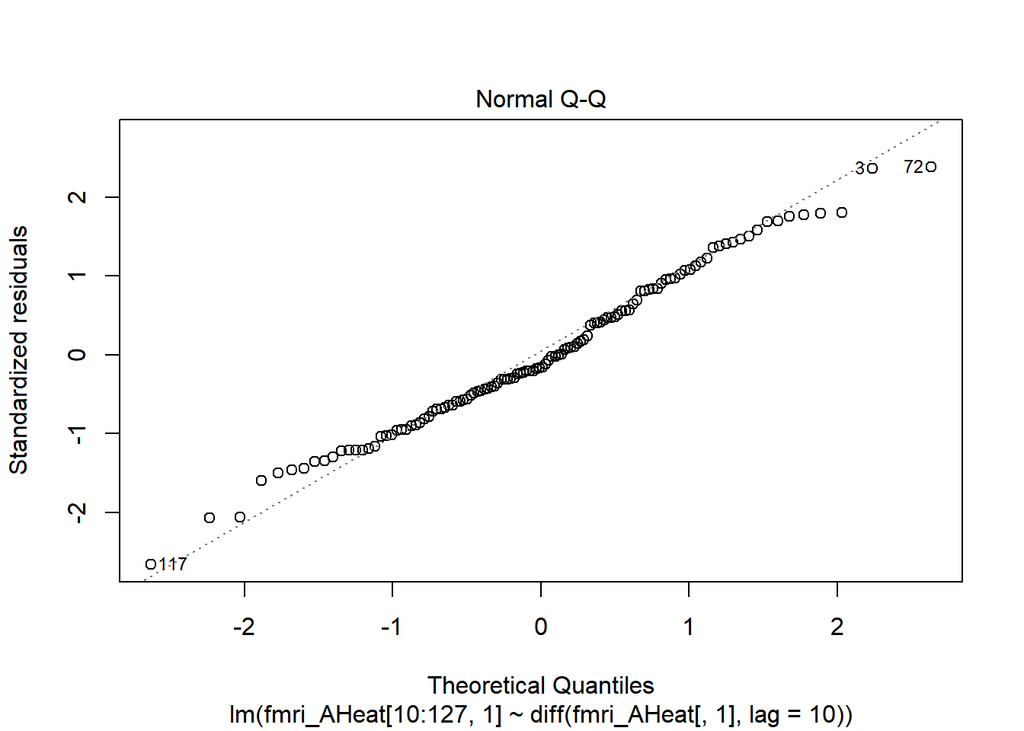

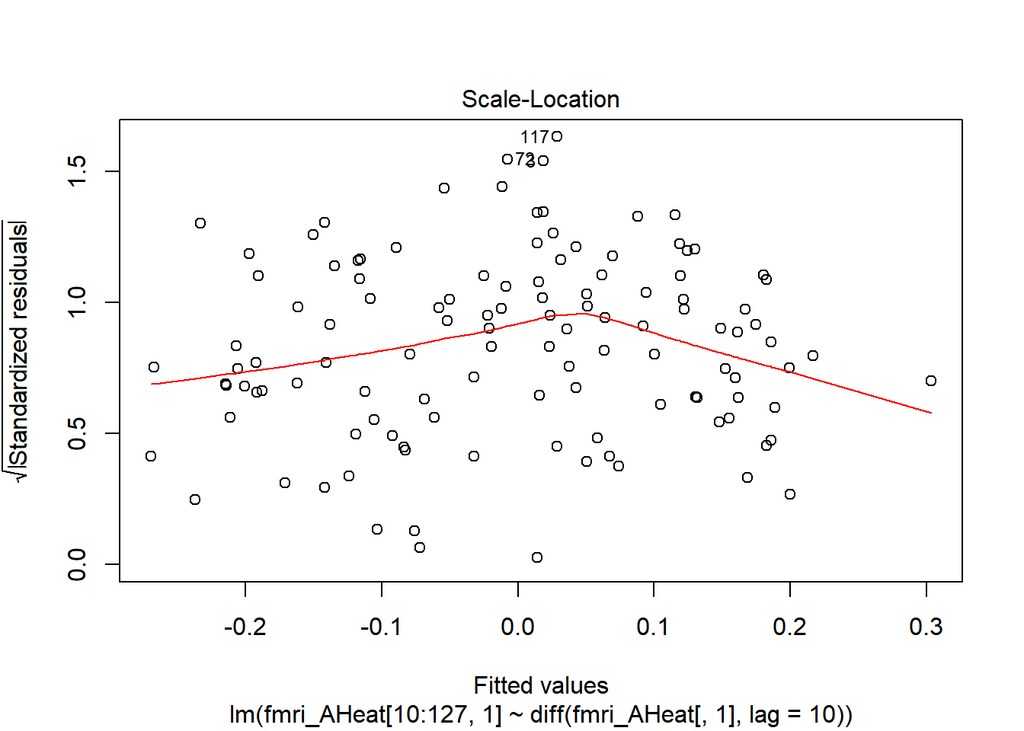

```r
plot(fit)
```

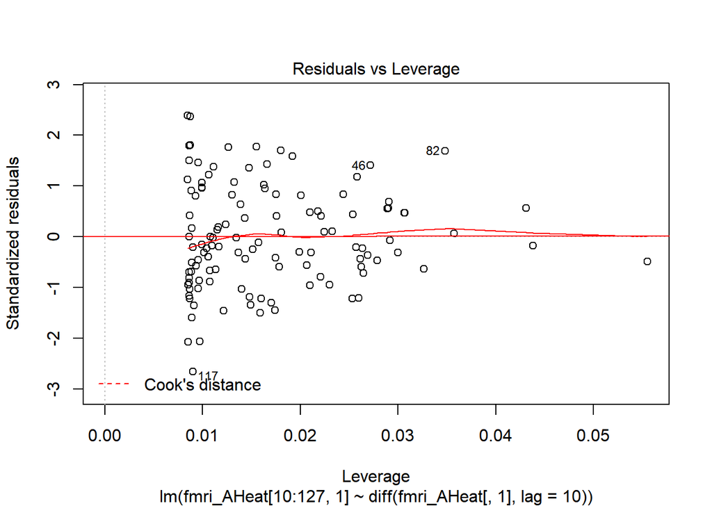

```r
abline(fit, col=2)
```

```r
#Check correlation
cor(fmri_AHeat[,1],fmri_AHeat[,2],method=c("pearson","kendall","spearman"))
```

```
## [1] -0.6585919
```

## Let’s create a correlation matrix for Awake-Heat data to compare locations

```r
#Install Hmisc package:
#install.packages("Hmisc")
#Use rcorr() function
library("Hmisc")
```

Use corrplot() function to draw a correlogram. The function corrplot(), in the package of the same name, creates a graphical display of a correlation matrix, highlighting the most correlated variables in a data table.

```r
#Install corrplot
#install.packages("corrplot")
library(corrplot)
```

Correlation coefficients are colored according to the value. Correlation matrix can be also reordered according to the degree of association between variables. The function corrplot() takes the correlation matrix as the first argument. The second argument (type=“upper”) is used to display only the upper triangular of the correlation matrix.

#### Let’s combine correlogram with the significance test. We’ll use the result generated with rcorr() function [in Hmisc package]

Insignificant correlations are leaved blank Order method of the correlation matrix (“original” for original order (default), “AOE” for the angular order of the eigenvectors, “FPC” for the first principal component order, “hclust” for the hierarchical clustering order, “alphabet” for alphabetical order)

```r
#For Awake Heat
ah2 <- rcorr(as.matrix(fmri_AHeat))
ah2
```

```
##        pSS(C) pSS(I) sSS(C) sSS(I)   Cau Tha(C) Tha(I) Crb(C) Crb(I)
## pSS(C)   1.00  -0.66   0.75   0.55  0.36  -0.04   0.04   0.48   0.39
## pSS(I)  -0.66   1.00  -0.63  -0.52 -0.24   0.02   0.02  -0.47  -0.38
## sSS(C)   0.75  -0.63   1.00   0.57  0.31  -0.12   0.11   0.48   0.27
## sSS(I)   0.55  -0.52   0.57   1.00  0.15   0.06   0.04   0.29   0.24
## Cau      0.36  -0.24   0.31   0.15  1.00   0.06   0.04   0.33   0.15
## Tha(C)  -0.04   0.02  -0.12   0.06  0.06   1.00  -0.11   0.06   0.17
## Tha(I)   0.04   0.02   0.11   0.04  0.04  -0.11   1.00   0.01   0.04
## Crb(C)   0.48  -0.47   0.48   0.29  0.33   0.06   0.01   1.00   0.36
## Crb(I)   0.39  -0.38   0.27   0.24  0.15   0.17   0.04   0.36   1.00
##
## n= 128
##
##
## P
##        pSS(C) pSS(I) sSS(C) sSS(I) Cau    Tha(C) Tha(I) Crb(C) Crb(I)
## pSS(C)        0.0000 0.0000 0.0000 0.0000 0.6299 0.6213 0.0000 0.0000
## pSS(I) 0.0000        0.0000 0.0000 0.0065 0.7802 0.8061 0.0000 0.0000
## sSS(C) 0.0000 0.0000        0.0000 0.0004 0.1806 0.2077 0.0000 0.0019
## sSS(I) 0.0000 0.0000 0.0000        0.1023 0.5200 0.6275 0.0009 0.0064
## Cau    0.0000 0.0065 0.0004 0.1023        0.4890 0.6234 0.0001 0.0819
## Tha(C) 0.6299 0.7802 0.1806 0.5200 0.4890        0.2056 0.5037 0.0503
## Tha(I) 0.6213 0.8061 0.2077 0.6275 0.6234 0.2056        0.9466 0.6436
## Crb(C) 0.0000 0.0000 0.0000 0.0009 0.0001 0.5037 0.9466        0.0000
## Crb(I) 0.0000 0.0000 0.0019 0.0064 0.0819 0.0503 0.6436 0.0000
```

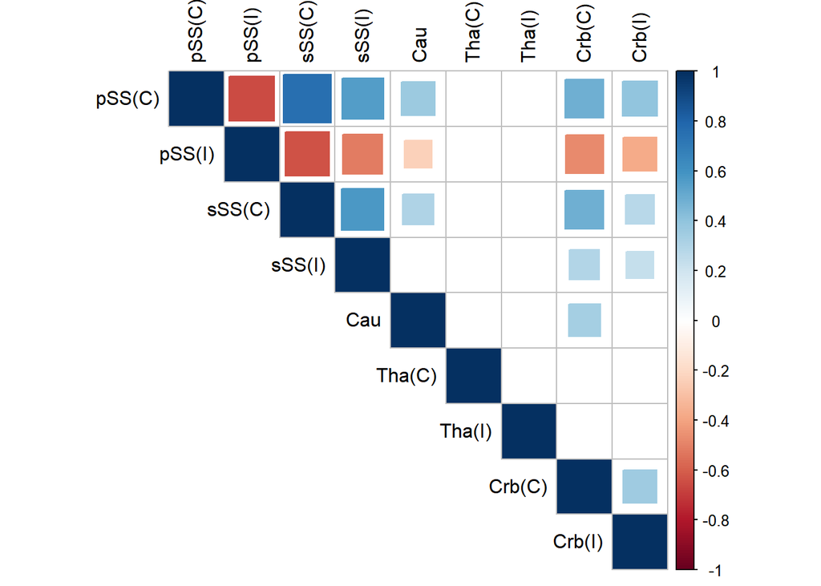

```r
corrplot(ah2$r,method="square", type="upper",
          p.mat = ah2$P, sig.level = 0.01, insig = "blank",
         tl.col="black")
```

### Sedated Heat

```r
summary(fmri_SHeat)
```

```
##      pSS(C)               pSS(I)             sSS(C)
##  Min.   :-0.4384460   Min.   :-0.54866   Min.   :-0.453900
##  1st Qu.:-0.1633030   1st Qu.:-0.15743   1st Qu.:-0.156839
##  Median :-0.0287713   Median :-0.05273   Median :-0.023045
##  Mean   : 0.0006995   Mean   :-0.01509   Mean   :-0.009446
##  3rd Qu.: 0.1461147   3rd Qu.: 0.13694   3rd Qu.: 0.085399
##  Max.   : 0.4589312   Max.   : 0.69830   Max.   : 0.572615
##      sSS(I)               Cau                Tha(C)
##  Min.   :-0.390862   Min.   :-0.557056   Min.   :-0.46224
##  1st Qu.:-0.109010   1st Qu.:-0.168200   1st Qu.:-0.13302
##  Median :-0.014474   Median :-0.020078   Median :-0.02574
##  Mean   :-0.003141   Mean   :-0.003044   Mean   : 0.00250
##  3rd Qu.: 0.112610   3rd Qu.: 0.180125   3rd Qu.: 0.15782
##  Max.   : 0.366521   Max.   : 0.529722   Max.   : 0.52691
##      Tha(I)              Crb(C)               Crb(I)
##  Min.   :-0.424822   Min.   :-0.5012840   Min.   :-0.541988
##  1st Qu.:-0.190478   1st Qu.:-0.1780668   1st Qu.:-0.212019
##  Median :-0.026140   Median :-0.0187421   Median : 0.026442
##  Mean   :-0.003291   Mean   :-0.0001761   Mean   :-0.003654
##  3rd Qu.: 0.153527   3rd Qu.: 0.1609289   3rd Qu.: 0.177965
##  Max.   : 0.614904   Max.   : 0.5192302   Max.   : 0.478846
```

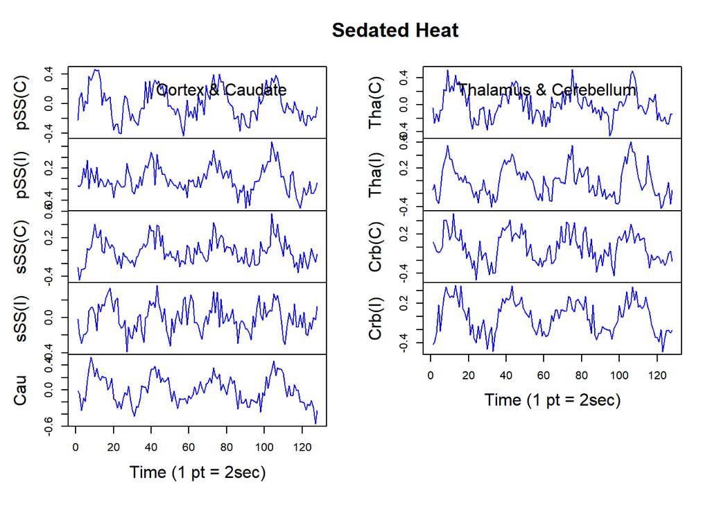

```r
plot.ts(fmri_SHeat,col=4,xlab="Time (1 pt = 2sec)", main="Sedated Heat")

#Show subtitles
mtext("Cortex & Caudate", side=3, adj=.05, line=-0.8)
mtext("Thalamus & Cerebellum", side=3, adj=.95, line=-0.8)
```

####Correlation Martix for the Sedated Heat stimulus

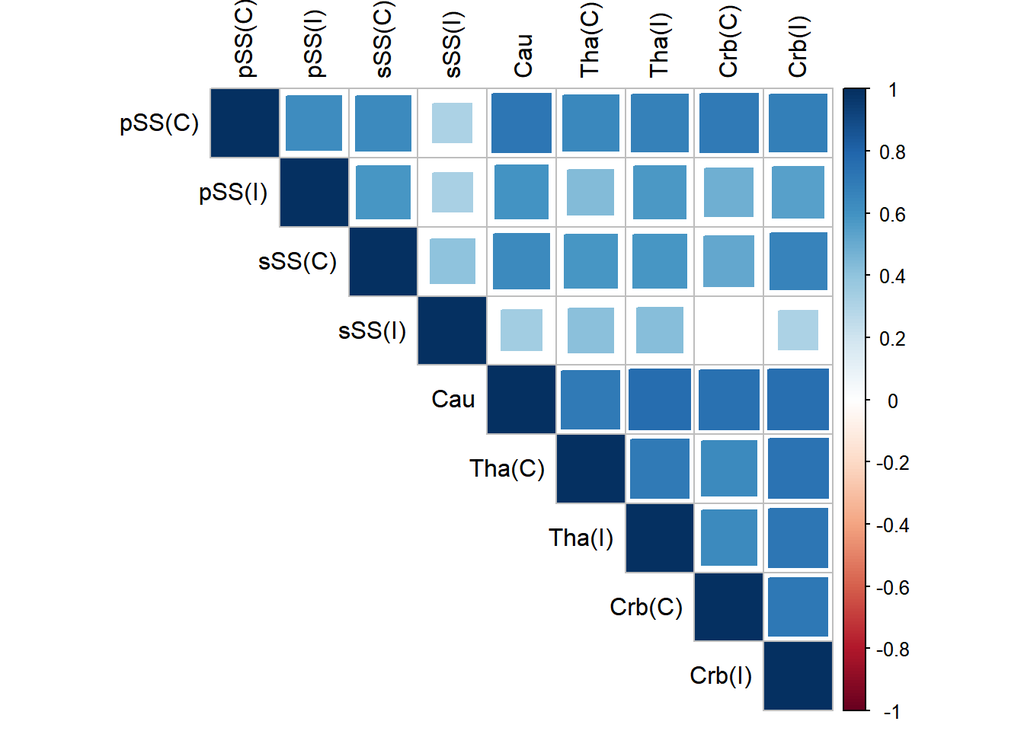

```r
#For Sedated Heat
sh2 <- rcorr(as.matrix(fmri_SHeat))
#sh2

corrplot(sh2$r,method="square", type="upper",
          p.mat = sh2$P, sig.level = 0.01, insig = "blank",
         tl.col="black")
```

## Depiction of the response to Shock

### Awake

```r
summary(fmri_AShock)
```

```
##      pSS(C)               pSS(I)              sSS(C)
##  Min.   :-0.5788860   Min.   :-0.642810   Min.   :-0.4890620
##  1st Qu.:-0.2384460   1st Qu.:-0.189344   1st Qu.:-0.1727537
##  Median : 0.0299180   Median : 0.052223   Median : 0.0604111
##  Mean   :-0.0000555   Mean   : 0.001138   Mean   : 0.0007217
##  3rd Qu.: 0.2071076   3rd Qu.: 0.190702   3rd Qu.: 0.1761580
##  Max.   : 0.5673700   Max.   : 0.554542   Max.   : 0.3950588
##      sSS(I)               Cau               Tha(C)
##  Min.   :-0.598918   Min.   :-0.36763   Min.   :-0.414554
##  1st Qu.:-0.199910   1st Qu.:-0.12817   1st Qu.:-0.100380
##  Median : 0.017946   Median : 0.01037   Median : 0.011611
##  Mean   :-0.008124   Mean   :-0.01113   Mean   : 0.005084
##  3rd Qu.: 0.165765   3rd Qu.: 0.09594   3rd Qu.: 0.126833
##  Max.   : 0.522088   Max.   : 0.39309   Max.   : 0.418879
##      Tha(I)              Crb(C)               Crb(I)
##  Min.   :-0.451624   Min.   :-0.3793080   Min.   :-0.483572
##  1st Qu.:-0.131307   1st Qu.:-0.1127138   1st Qu.:-0.225864
##  Median :-0.028489   Median :-0.0000112   Median : 0.029049
##  Mean   :-0.008268   Mean   : 0.0020727   Mean   :-0.007777
##  3rd Qu.: 0.093612   3rd Qu.: 0.1077604   3rd Qu.: 0.188645
##  Max.   : 0.573082   Max.   : 0.4319380   Max.   : 0.484577
```

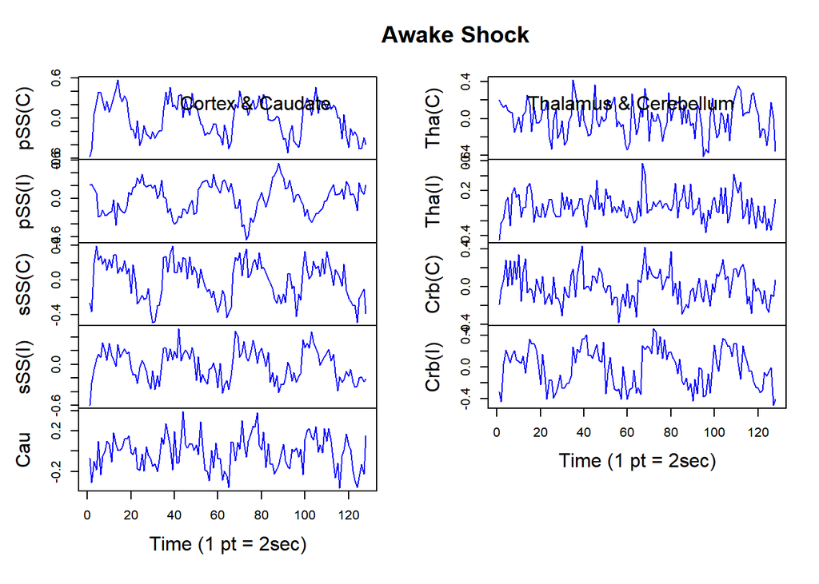

```r
plot.ts(fmri_AShock,col=4,xlab="Time (1 pt = 2sec)", main="Awake Shock")

#Show subtitles
mtext("Cortex & Caudate", side=3, adj=.05, line=-0.8)
mtext("Thalamus & Cerebellum", side=3, adj=.95, line=-0.8)
```

Observations:similar response to heat. More pronounced sinusoid shape of the response in pSSC and Crb(I) that closely resemble each other.

#### Correlation Martix for the Awake Shock stimulus

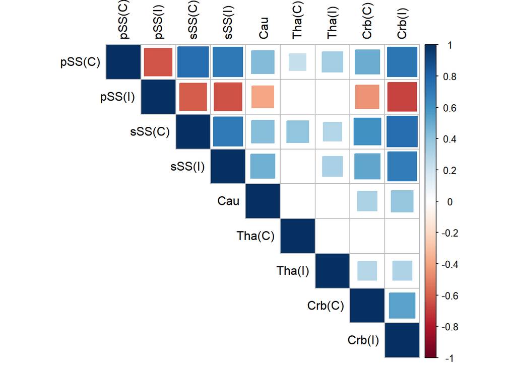

```r
as2 <- rcorr(as.matrix(fmri_AShock))
#as2

corrplot(as2$r,method="square", type="upper",
          p.mat = as2$P, sig.level = 0.01, insig = "blank",
         tl.col="black")
```

### Sedated

```r
summary(fmri_SShock)
```

```
##      pSS(C)              pSS(I)              sSS(C)
##  Min.   :-0.441220   Min.   :-0.528228   Min.   :-0.3849040
##  1st Qu.:-0.100000   1st Qu.:-0.124613   1st Qu.:-0.1025911
##  Median : 0.007961   Median :-0.004894   Median :-0.0094061
##  Mean   : 0.005106   Mean   : 0.002164   Mean   :-0.0009082
##  3rd Qu.: 0.117299   3rd Qu.: 0.119430   3rd Qu.: 0.1084434
##  Max.   : 0.525298   Max.   : 0.489470   Max.   : 0.3777587
##      sSS(I)               Cau                 Tha(C)
##  Min.   :-0.400961   Min.   :-0.3966345   Min.   :-0.434470
##  1st Qu.:-0.142623   1st Qu.:-0.1185899   1st Qu.:-0.124874
##  Median :-0.016437   Median :-0.0002671   Median : 0.007323
##  Mean   :-0.006824   Mean   : 0.0008962   Mean   :-0.005425
##  3rd Qu.: 0.123118   3rd Qu.: 0.0927818   3rd Qu.: 0.100947
##  Max.   : 0.583695   Max.   : 0.5460738   Max.   : 0.362248
##      Tha(I)               Crb(C)              Crb(I)
##  Min.   :-0.3941968   Min.   :-0.363264   Min.   :-0.399714
##  1st Qu.:-0.1302176   1st Qu.:-0.108369   1st Qu.:-0.125569
##  Median :-0.0030451   Median :-0.003344   Median : 0.016156
##  Mean   :-0.0005887   Mean   : 0.005404   Mean   : 0.005079
##  3rd Qu.: 0.0847043   3rd Qu.: 0.107093   3rd Qu.: 0.144693
##  Max.   : 0.4321722   Max.   : 0.391026   Max.   : 0.456645
```

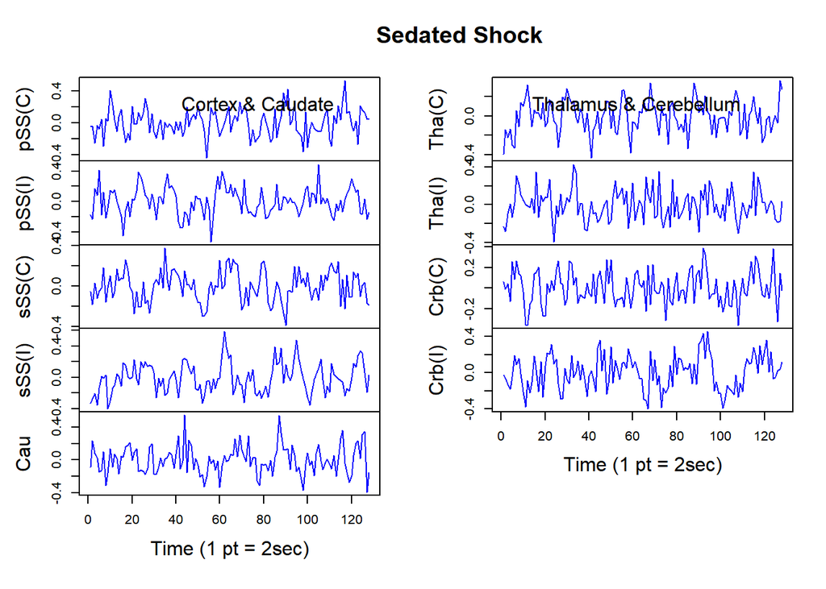

```r
plot.ts(fmri_SShock,col=4,xlab="Time (1 pt = 2sec)", main="Sedated Shock")

#Show subtitles
mtext("Cortex & Caudate", side=3, adj=.05, line=-0.8)
mtext("Thalamus & Cerebellum", side=3, adj=.95, line=-0.8)
```

Observations: WN? while sedated

#### Correlation Martix for the Sedated Shock stimulus

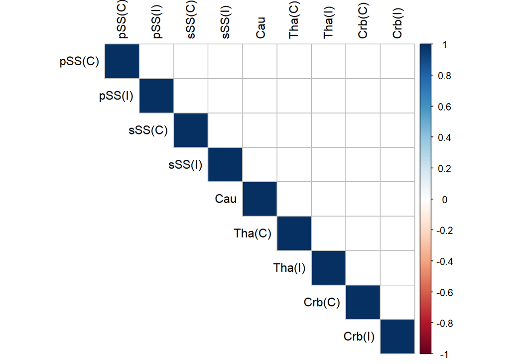

```r
ss2 <- rcorr(as.matrix(fmri_SShock))
#ss2

corrplot(ss2$r,method="square", type="upper",
          p.mat = ss2$P, sig.level = 0.01, insig = "blank",
         tl.col="black")
```

```r
#ts.plot(as.ts(fmri_AShock[,1]), as.ts(fmri_SShock[,1]),col=3:4,xlab="Time (1 pt = 2sec)", main="Shock")
#legend('topright', legend=c("Awake","Sedated"), lty=1, col=3:4)
```

# Data Decomposition

### Decompose and plot Awake Heat data based on the combined locations with the highest significance for correlation

### into trends, seasons, residuals

To use decompose function the frequency has to equal at least 2. Decompose() function makes seasonal adjustments using moving average, depicts original ts, trend, seasonal, and random (remainder) part

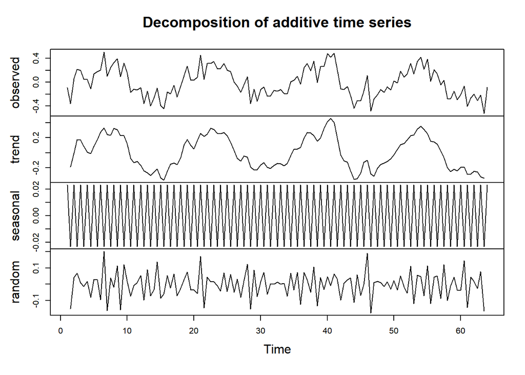

```r
# pSS, sSS, Crb(C)
fmri_AHeat1<-ts(c(fmri_AHeat[,1],fmri_AHeat[,2],fmri_AHeat[,3],fmri_AHeat[,4],fmri_AHeat[,8]), start=1, end=64, frequency=2)
#is.ts(fmri_AHeat1)
#fmri_AHeat1
m1<-decompose(fmri_AHeat1)
plot(m1)
```

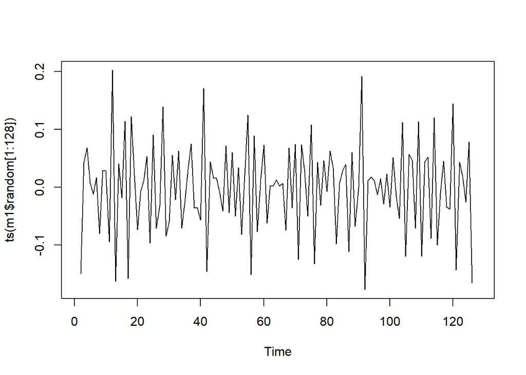

```r
plot(ts(m1$random[1:128]))
```

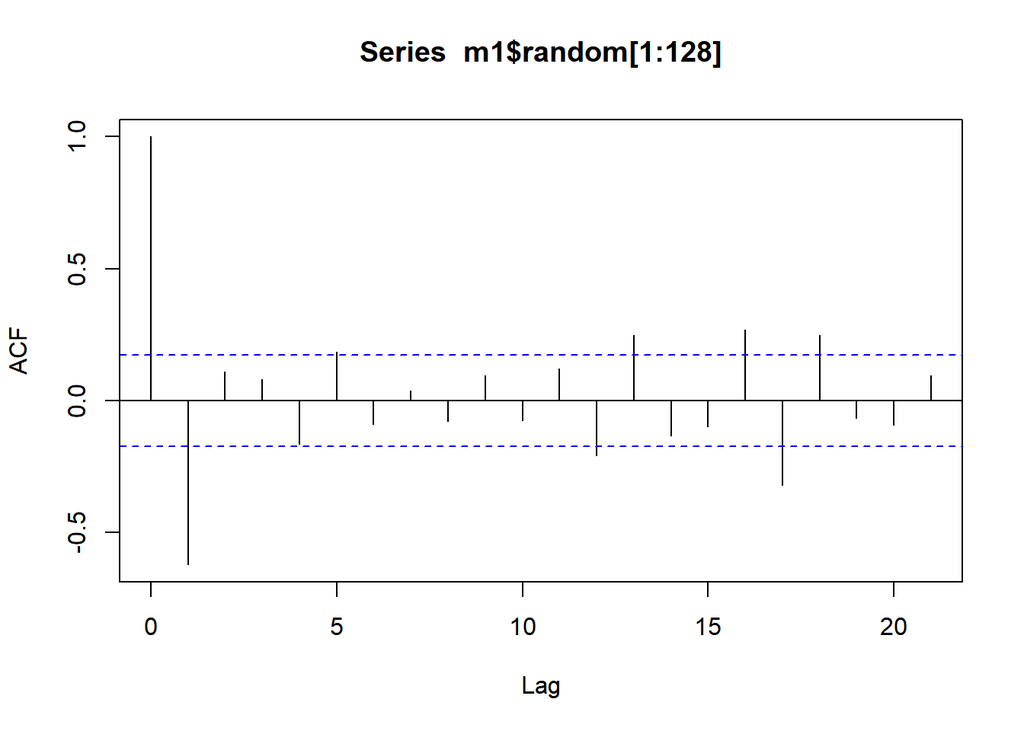

```r
acf(m1$random[1:128], na.action=na.pass) #plots autocovariance or autocorrelation
```

## Reduce seasonal effect by aggregating data using aggregate() and cycle()

## Show boxplot with a cycle

[figure not shown]

```r
#Check for NA values
m1$random[1:128]
```

```
##   [1]           NA -0.149938523  0.042498023  0.068290664  0.007602211
##   [6] -0.012289711  0.016902773 -0.080518836  0.028881961  0.028558477
##  [11] -0.094704289  0.202516789 -0.163231102  0.040612039 -0.018290602
##  [16]  0.114495977 -0.158097164  0.122159664  0.020697461 -0.073822398
##  [21] -0.007502039  0.011519852  0.053435586 -0.096739211  0.090563586
##  [26] -0.071441523 -0.031683414  0.139123852 -0.084882852 -0.059313523
##  [31]  0.055295648 -0.021739086  0.062884898 -0.070920586 -0.025433539
##  [36]  0.030418539  0.075236273 -0.035876086 -0.035106102 -0.056858211
##  [41]  0.171143898 -0.146515836  0.043837273  0.015909727  0.015117023
##  [46] -0.009462273 -0.041653789  0.071638914 -0.044406727  0.060254914
##  [51] -0.050507914  0.033618039 -0.081832289  0.020894727  0.124789836
##  [56] -0.151873148  0.088926648 -0.076947461  0.014521898  0.072829289
##  [61] -0.062561414  0.002367977  0.001947461  0.012412602  0.001724336
##  [66]  0.006534664 -0.074466227  0.068513789 -0.035775664  0.074242977
##  [71] -0.125061477  0.073573352  0.027245086 -0.050310523  0.107825398
##  [76] -0.132825398  0.043093336 -0.031486211  0.046143836 -0.007304523
##  [81]  0.062736086  0.032725227 -0.098424602  0.005641852  0.028509961
##  [86]  0.038900664 -0.111445289  0.060031664 -0.067695352 -0.000608211
##  [91]  0.191828398 -0.177468273  0.011248023  0.017472227  0.011694461
##  [96] -0.012810586  0.014819523 -0.029030773  0.022706336 -0.034462273
## [101]  0.051054586 -0.014670711 -0.054451352  0.112115039 -0.119704289
## [106]  0.056981039  0.046515961 -0.071441461  0.113703398 -0.120027836
## [111]  0.043837336  0.051847164 -0.088751914  0.120522727 -0.099912602
## [116] -0.010429648  0.045474273 -0.034536711 -0.038305602  0.144927539
## [121] -0.143588164  0.043365039  0.017721211 -0.025757023  0.078063648
## [126] -0.166084461           NA           NA
```

# Calculate st dev to check if the decomposition made any effect

```r
sd(fmri_AHeat1)
```

```
## [1] 0.241536
```

```r
sd(fmri_AHeat1[2:126] - m1$trend[2:126])
```

```
## [1] 0.08224404
```

```r
sd(m1$random[2:126])
```

```
## [1] 0.07887631
```

### Observations: The reduction in the standard deviation shows that the seasonal adjustment has been effective.

## Reduce seasonal effect by aggregating data using aggregate() and cycle() .

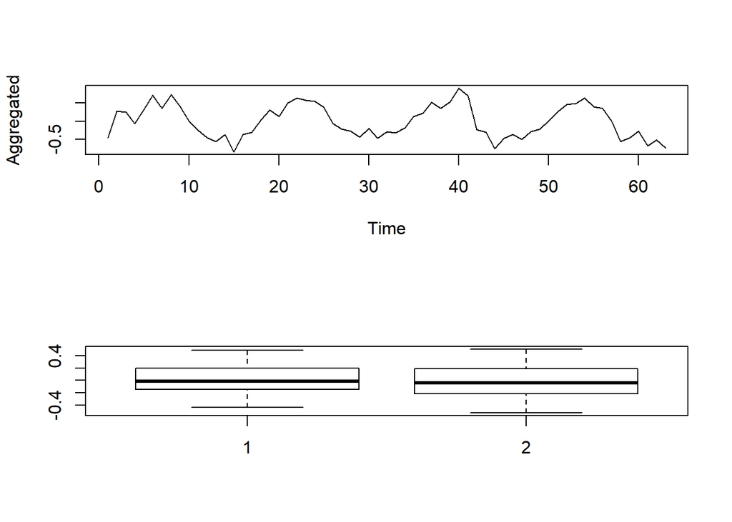

### Decompose Sedated Heat data based on the combined locations with the highest significance for correlation

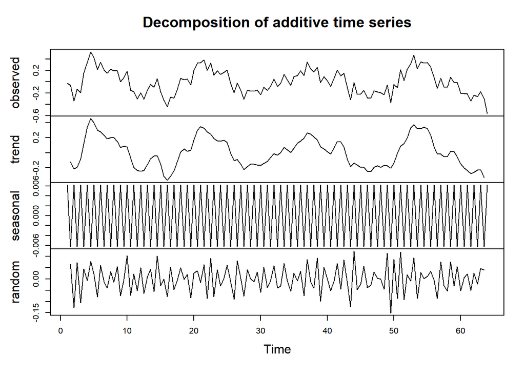

```r
# Caudate, Thalamus and Cerebellum
fmri_SHeat1<-ts(c(fmri_SHeat[,5],fmri_SHeat[,6],fmri_SHeat[,7],fmri_SHeat[,8],fmri_SHeat[,9]), start=1, end=64, frequency=2)

m2<-decompose(fmri_SHeat1)
plot(m2)
```

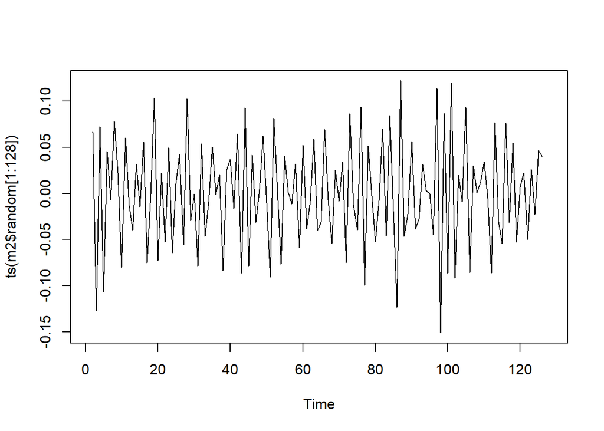

```r
plot(ts(m2$random[1:128]))
```

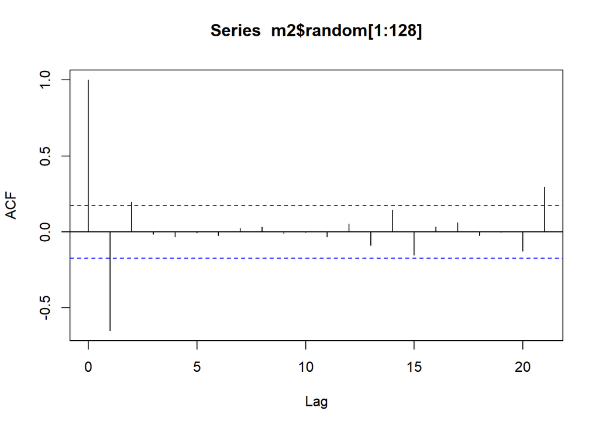

```r
acf(m2$random[1:128], na.action=na.pass) #plots autocovariance or autocorrelation
```

# Calculate st dev to check if the decomposition made any effect

```r
sd(fmri_SHeat1)
```

```
## [1] 0.2167146
```

```r
sd(fmri_SHeat1[2:126] - m2$trend[2:126])
```

```
## [1] 0.05976221
```

```r
sd(m2$random[2:126])
```

```
## [1] 0.05943562
```

### Decompose Awake Shock data based on the combined locations with the highest significance for correlation

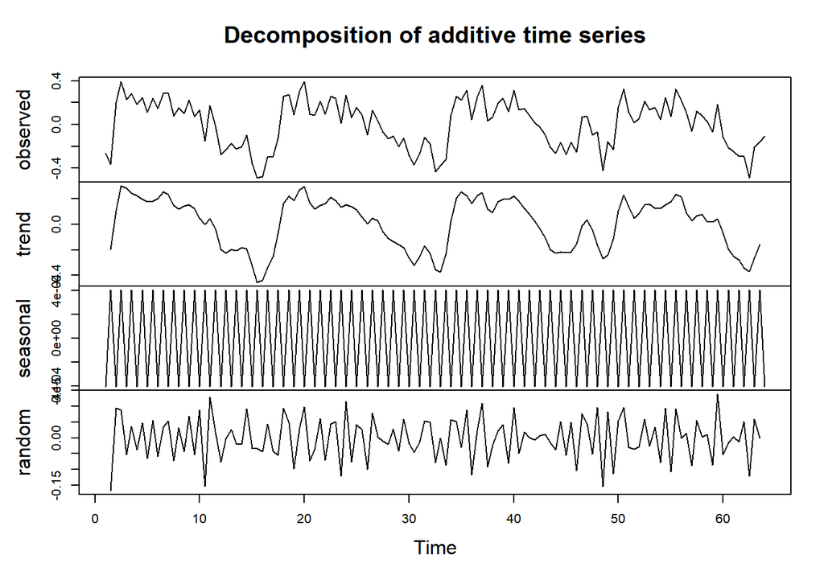

```r
# sSS + Crb(I)
fmri_AShock1<-ts(c(fmri_AShock[,3],fmri_AShock[,4],fmri_AShock[,9]), start=1, end=64, frequency=2)

m3<-decompose(fmri_AShock1)
plot(m3)
```

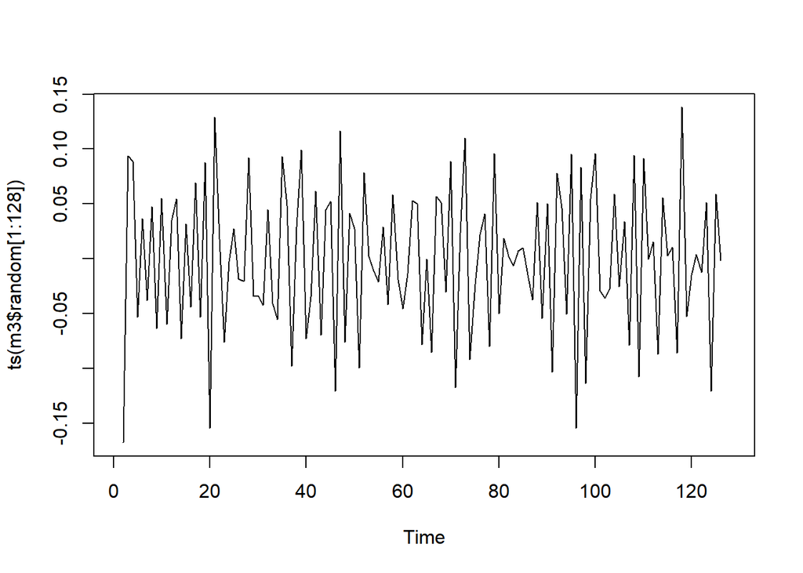

```r
plot(ts(m3$random[1:128]))
```

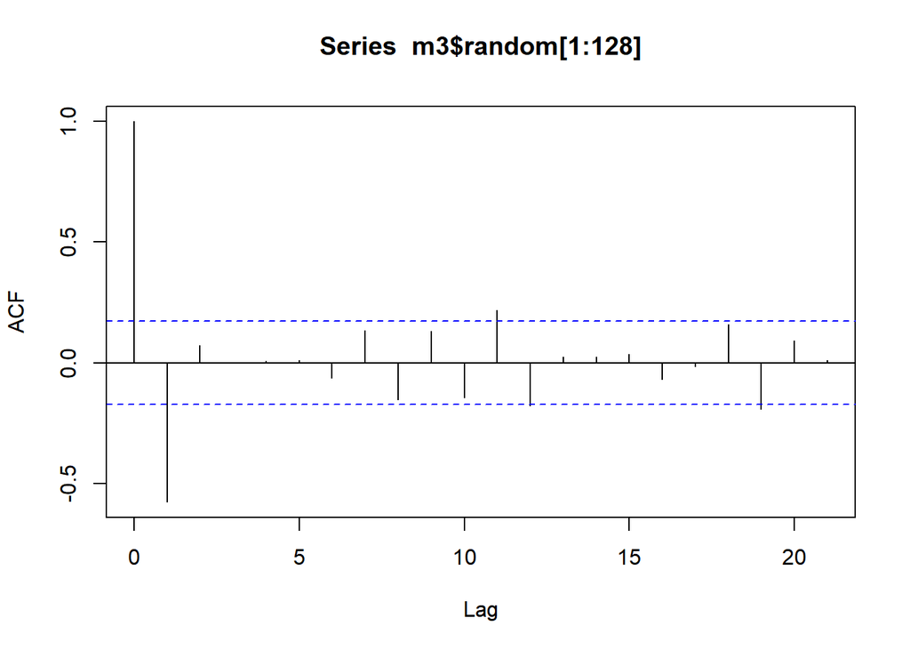

```r
acf(m3$random[1:128], na.action=na.pass) #plots autocovariance or autocorrelation
```

# Calculate st dev to check if the decomposition made any effect

```r
sd(fmri_AShock1)
```

```
## [1] 0.2197597
```

```r
sd(fmri_AShock1[2:126] - m3$trend[2:126])
```

```
## [1] 0.06730194
```

```r
sd(m3$random[2:126])
```

```
## [1] 0.06730071
```

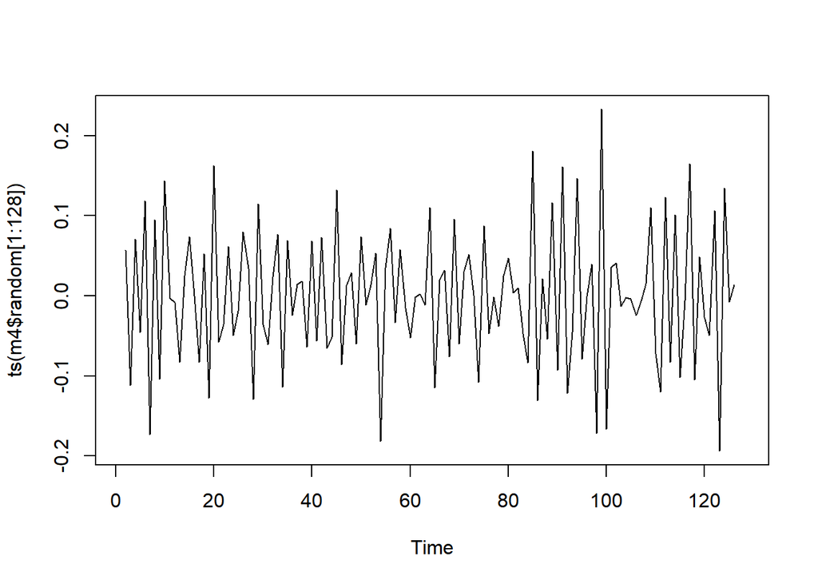

```r
#pSS
fmri_SShock1<-ts(c(fmri_SShock[,1],fmri_AShock[,2]), start=1, end=64, frequency=2)

m4<-decompose(fmri_SShock1)
plot(ts(m4$random[1:128]))
```

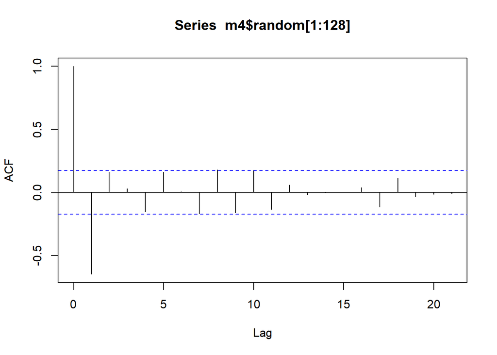

```r
acf(m4$random[1:128], na.action=na.pass) #plots autocovariance or autocorrelation
```

# Calculate st dev to check if the decomposition made any effect

```r
sd(fmri_SShock1)
```

```
## [1] 0.1678594
```

```r
sd(fmri_SShock1[2:126] - m4$trend[2:126])
```

```
## [1] 0.08490597
```

```r
sd(m4$random[2:126])
```

```
## [1] 0.08490013
```

# Let’s check if it is White Noise.

## WN assumptions:

### 95% of values ~= 0 and lay inside the blue lines

### They should be uncorrelated

### They should have mean zero

Useful properties (for computing prediction intervals) ### They should have constant variance ### They should be normally distributed

# Use Ljung-Box test to check for WN

The Ljung-Box test considers the first h autocorrelation values together.

```r
Box.test(fmri_SShock1, lag = 16, fitdf = 0, type = "Lj")
```

```
##
##  Box-Ljung test
##
## data:  fmri_SShock1
## X-squared = 29.947, df = 16, p-value = 0.01828
```

# Summary:

We can test for white noise by looking at an ACF plot or by doing a Ljung-Box test

# Forecasts and potential futures

The 80% forecast intervals should contain 80% of the future observations The 95% forecast intervals should contain 95% of the future observations

### time() function calculates a vector of time indices, with one element for each time index on which the series was observed.

```r
 time(fmri_AHeat1)
```

```
## Time Series:
## Start = c(1, 1)
## End = c(64, 1)
## Frequency = 2
##   [1]  1.0  1.5  2.0  2.5  3.0  3.5  4.0  4.5  5.0  5.5  6.0  6.5  7.0  7.5
##  [15]  8.0  8.5  9.0  9.5 10.0 10.5 11.0 11.5 12.0 12.5 13.0 13.5 14.0 14.5
##  [29] 15.0 15.5 16.0 16.5 17.0 17.5 18.0 18.5 19.0 19.5 20.0 20.5 21.0 21.5
##  [43] 22.0 22.5 23.0 23.5 24.0 24.5 25.0 25.5 26.0 26.5 27.0 27.5 28.0 28.5
##  [57] 29.0 29.5 30.0 30.5 31.0 31.5 32.0 32.5 33.0 33.5 34.0 34.5 35.0 35.5
##  [71] 36.0 36.5 37.0 37.5 38.0 38.5 39.0 39.5 40.0 40.5 41.0 41.5 42.0 42.5
##  [85] 43.0 43.5 44.0 44.5 45.0 45.5 46.0 46.5 47.0 47.5 48.0 48.5 49.0 49.5
##  [99] 50.0 50.5 51.0 51.5 52.0 52.5 53.0 53.5 54.0 54.5 55.0 55.5 56.0 56.5
## [113] 57.0 57.5 58.0 58.5 59.0 59.5 60.0 60.5 61.0 61.5 62.0 62.5 63.0 63.5
## [127] 64.0
```

### deltat() function returns the fixed time interval between observations

```r
deltat(fmri_AHeat1)
```

```
## [1] 0.5
```

### frequency() function returns the number of observations per unit time.

```r
 frequency(fmri_AHeat1)
```

```
## [1] 2
```

#### cycle() function returns the position in the cycle of each observation.

```r
 cycle(fmri_AHeat1)
```

```
## Time Series:
## Start = c(1, 1)
## End = c(64, 1)
## Frequency = 2
##   [1] 1 2 1 2 1 2 1 2 1 2 1 2 1 2 1 2 1 2 1 2 1 2 1 2 1 2 1 2 1 2 1 2 1 2 1
##  [36] 2 1 2 1 2 1 2 1 2 1 2 1 2 1 2 1 2 1 2 1 2 1 2 1 2 1 2 1 2 1 2 1 2 1 2
##  [71] 1 2 1 2 1 2 1 2 1 2 1 2 1 2 1 2 1 2 1 2 1 2 1 2 1 2 1 2 1 2 1 2 1 2 1
## [106] 2 1 2 1 2 1 2 1 2 1 2 1 2 1 2 1 2 1 2 1 2 1
```

# ARMA/ARIMA model

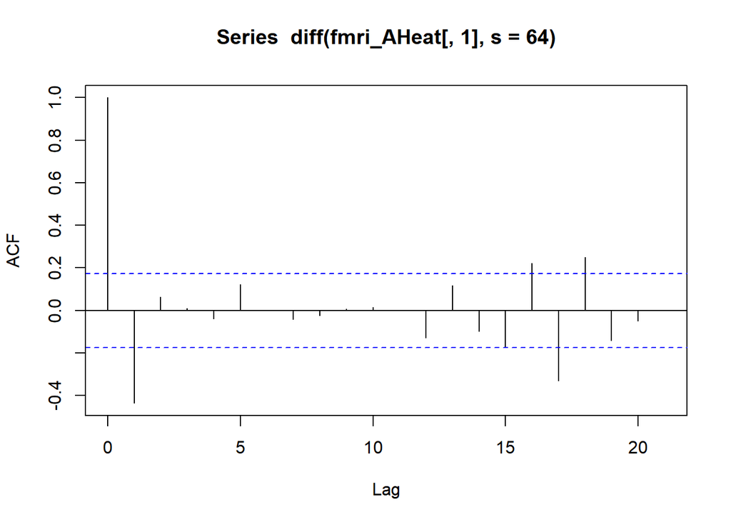

```r
#compute seasonally adjusted (and by default plot) estimates of the autocovariance or autocorrelation function.
acf(diff(fmri_AHeat[,1], s=64))
```

Observations: depicts cyclic nature of the data. The correlations cut off by lag 10 and re-institutes itself for lags 15 through 20 (ARIMA model)

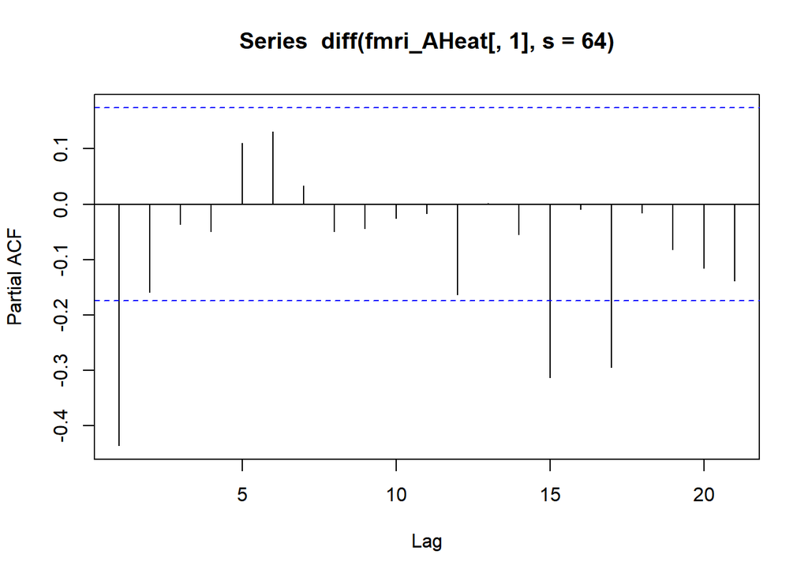

```r
#Used for the partial autocorrelations.
pacf(diff(fmri_AHeat[,1], s=64))
```

Observations: Similar cyclic however stationary behavior was observed. Predicted ARIMA model

# Model Diagnostics

build ARIMA model with various p, d, q [for d - see https://people.duke.edu/~rnau/411arim2.htm]

```r
#select the best model
library(forecast)
```

```r
fit2 <- auto.arima(fmri_AHeat.ts[,1])
summary(fit2)
```

```
## Series: fmri_AHeat.ts[, 1]
## ARIMA(2,0,0) with zero mean
##
## Coefficients:
##          ar1     ar2
##       0.4485  0.3290
## s.e.  0.0832  0.0839
##
## sigma^2 estimated as 0.02859:  log likelihood=46.46
## AIC=-86.93   AICc=-86.73   BIC=-78.37
##
## Training set error measures:
##                       ME      RMSE       MAE      MPE    MAPE      MASE
## Training set -0.00174074 0.1677735 0.1345035 104.6922 271.387 0.8654695
##                     ACF1
## Training set -0.01784832
```

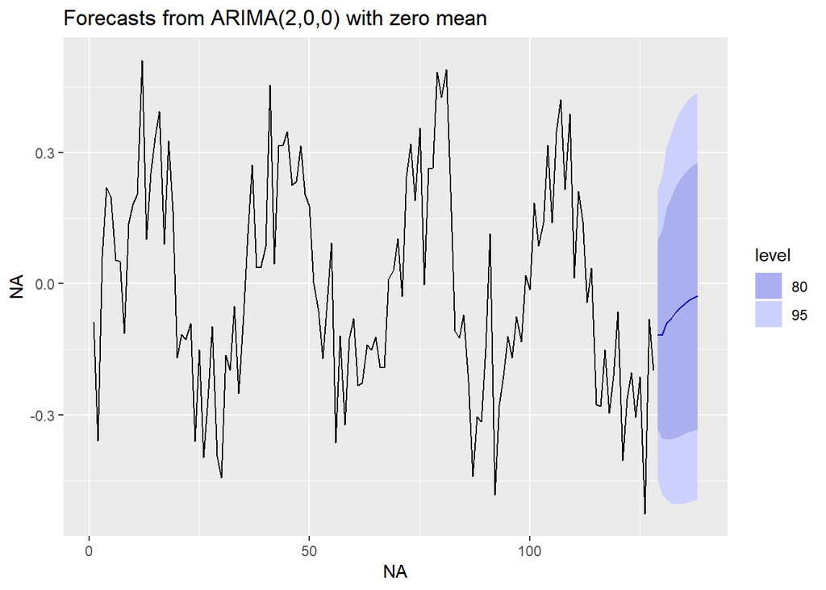

```r
#Show predicted values
fit2 %>% forecast() %>% autoplot()
```

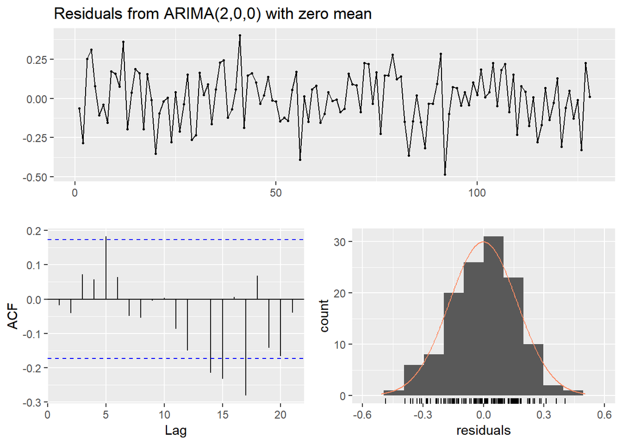

```
##
##  Ljung-Box test
##
## data:  Residuals from ARIMA(2,0,0) with zero mean
## Q* = 7.1688, df = 8, p-value = 0.5185
##
## Model df: 2.   Total lags used: 10
```

```r
checkresiduals(fit2)
```

Observations: Residuals are N-distributed with mean=0 and provide an adequete fit.

```r
#Check for the best fit based on AIC and BIC from MA and AR models
MA_fit <- arima(fmri_AHeat.ts[,1], order = c(0,0,1))

AIC(MA_fit)
```

```
## [1] -37.21717
```

```r
BIC(MA_fit)
```

```
## [1] -28.66108
```

```r
AR_fit <- arima(fmri_AHeat.ts[,1], order = c(1,0,0))

AIC(AR_fit)
```

```
## [1] -72.49685
```

```r
BIC(AR_fit)
```

```
## [1] -63.94076
```

Observation: Akaike Information Criterion (AIC) and Bayesian Information Criterion (BIC) are the smallest for the AR model that would confirm the best fit for our model.

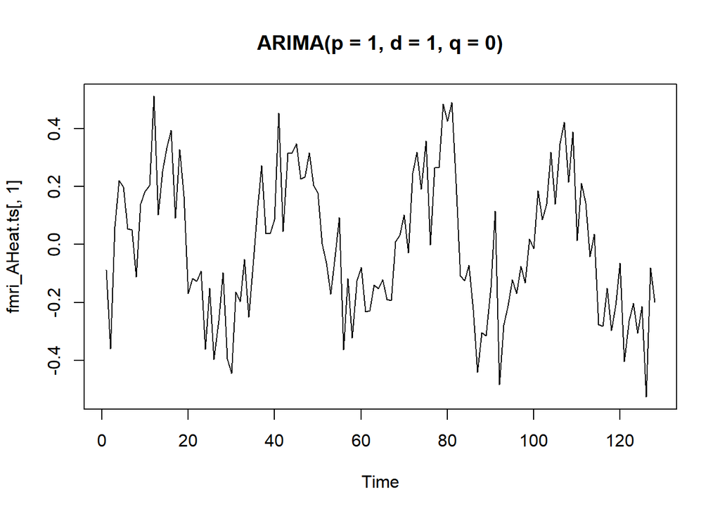

```r
#Check for ARMA behavior
plot(fmri_AHeat.ts[,1], main = "ARIMA(p = 1, d = 1, q = 0)")
```

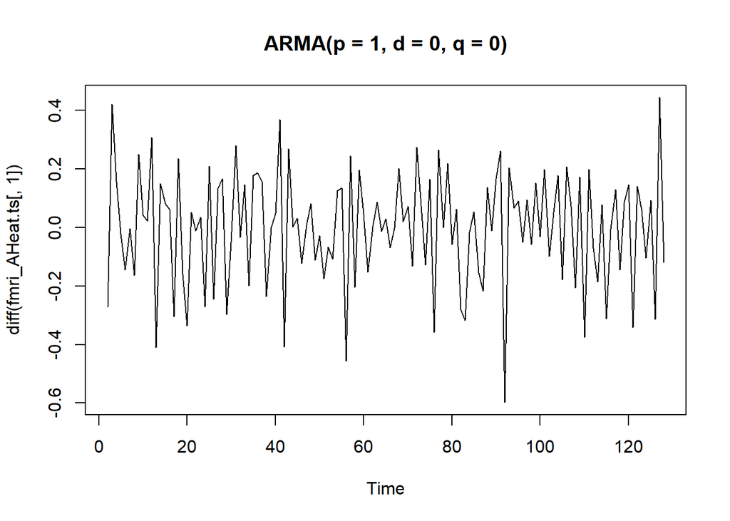

```r
plot(diff(fmri_AHeat.ts[,1]), main = "ARMA(p = 1, d = 0, q = 0)")
```

```r
#Fit an ARIMA model to a univariate time series
fitARIMA <- arima(diff(fmri_AHeat[,1]), order=c(2,0,0),seasonal = list(order = c(1,0,0), period = 32),method="ML")

#load for Diagnostic Checking in Regression Relationships
library(lmtest)
#Perform z and (quasi-)t Wald tests of estimated coefficients. Compute the corresponding Wald confidence intervals.
coeftest(fitARIMA)
```

```
##
## z test of coefficients:
##
##              Estimate  Std. Error z value  Pr(>|z|)
## ar1       -0.56085396  0.08695803 -6.4497 1.121e-10 ***
## ar2       -0.23552502  0.09046224 -2.6036  0.009226 **
## sar1       0.40247003  0.08988504  4.4776 7.548e-06 ***
## intercept -0.00034239  0.01134916 -0.0302  0.975932
## ---
## Signif. codes:  0 '***' 0.001 '**' 0.01 '*' 0.05 '.' 0.1 ' ' 1
```

```r
#Remove insignificant coefficients. Computes confidence intervals for one or more parameters in a fitted model
confint(fitARIMA)
```

```
##                 2.5 %      97.5 %
## ar1       -0.73128856 -0.39041935
## ar2       -0.41282776 -0.05822228
## sar1       0.22629858  0.57864149
## intercept -0.02258633  0.02190155
```

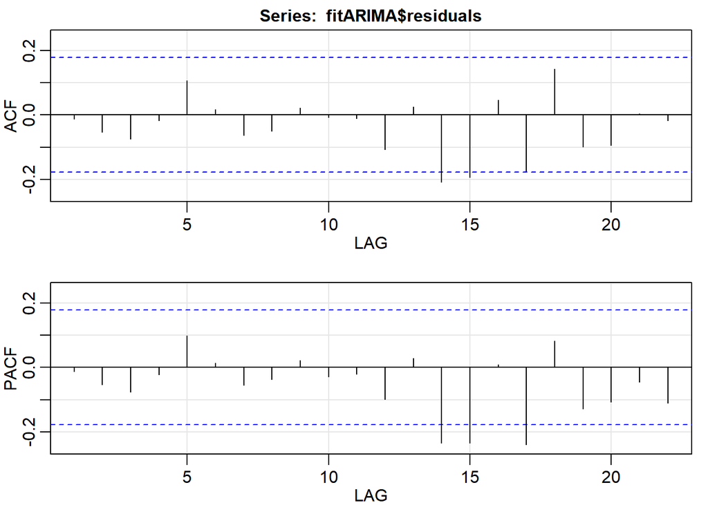

```
##         ACF  PACF
##  [1,] -0.01 -0.01
##  [2,] -0.05 -0.05
##  [3,] -0.07 -0.08
##  [4,] -0.02 -0.02
##  [5,]  0.11  0.10
##  [6,]  0.02  0.01
##  [7,] -0.06 -0.06
##  [8,] -0.05 -0.04
##  [9,]  0.02  0.02
## [10,] -0.01 -0.03
## [11,] -0.01 -0.02
## [12,] -0.11 -0.10
## [13,]  0.02  0.03
## [14,] -0.21 -0.23
## [15,] -0.19 -0.23
## [16,]  0.05  0.01
## [17,] -0.17 -0.24
## [18,]  0.14  0.08
## [19,] -0.10 -0.13
## [20,] -0.09 -0.11
## [21,]  0.00 -0.04
## [22,] -0.02 -0.11
```

```r
#estimate of the autocovariance or autocorrelation function
acf2(fitARIMA$residuals)
```

```r
#load to Fit AR and subset AR models and provide complete model building capabilities
library(FitAR)
```

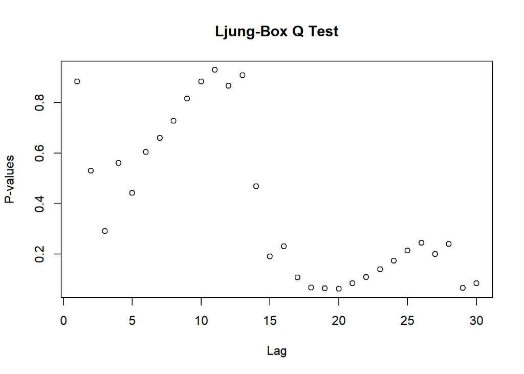

```r
#Ljung-Box Portmanteau test for the goodness of fit of ARIMA models
boxresult <- LjungBoxTest (fitARIMA$residuals,k=2,StartLag=1)

#Plot results
plot(boxresult[,3],main= "Ljung-Box Q Test", ylab= "P-values", xlab= "Lag")
```

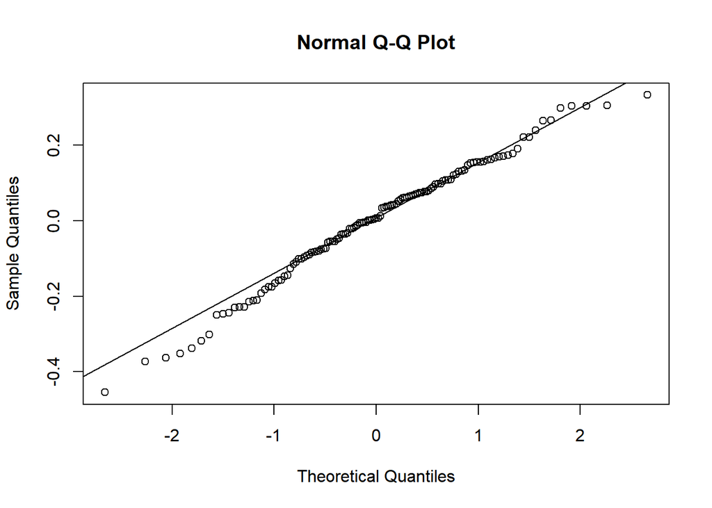

```r
#produce a normal QQ plot of the values in y. qqline adds a line to a "theoretical", by default normal, quantile-quantile plot which passes through the probs quantiles, by default the first and third quartiles.
qqnorm(fitARIMA$residuals)
qqline(fitARIMA$residuals)
```